# Mucopolysaccharidosis Immune-Related Phenotypes

2024-07-02

**First we need some R libraries:**

```r
#remotes::install_github("https://github.com/monarch-initiative/monarchr", ref = "engines")

suppressMessages({
    library(monarchr)
    library(ggraph)
    library(stringr) # for str_wrap
    library(tidygraph) # activate() etc.
})
```

**MONDO:0019249 is the generic Mucopolysaccharidosis (MPS), which has many subtypes. Let’s get all its subtypes, and all the phenotypes directly connected to any of those subtypes.**

```r
mps_phenos <- monarch_engine() |>
    fetch_nodes(query_ids = "MONDO:0019249") |>
    expand(predicates = "biolink:subclass_of", direction = "in", transitive = TRUE) |>
    expand(result_categories = c("biolink:PhenotypicFeature"))

mps_phenos
```

#### Nodes

Showing 100 of 439 nodes:

| id | pcategory | name | description | synonym (list) | category (list) | iri | xref (list) | provided_by (list) |
| --- | --- | --- | --- | --- | --- | --- | --- | --- |
| “MONDO:0019249” | “biolink:Disease” | “mucopolysaccharidosis” | “A group of autosomal recessive or X-linked inherited lysosomal storage disorders affecting the metabolism of mucopolysaccharides, resulting in the accumulation of mucopolysaccharides in the body. Sig… | c(“MPS”, “Mucopolysaccharidoses”, “mucopolysaccharidoses”, “mucopolysaccharidosis”) | c(“biolink:BiologicalEntity”, “biolink:Disease”, “biolink:DiseaseOrPhenotypicFeature”, “biolink:Entity”, “biolink:NamedThing”, “biolink:ThingWithTaxon”) | “http://purl.obolibrary.org/obo/MONDO_0019249” | c(“DOID:12798”, “GARD:7065”, “ICD9:277.5”, “MESH:D009083”, “MedDRA:10028093”, “NCIT:C61259”, “NORD:1461”, “OMIMPS:607014”, “Orphanet:79213”, “SCTID:11380006”, “UMLS:C0026703”, “icd11.foundation:159612… | “phenio_nodes” |
| “MONDO:0010674” | “biolink:Disease” | “mucopolysaccharidosis type 2” | “A lysosomal storage disease leading to a massive accumulation of glycosaminoglycans and a wide variety of symptoms including distinctive coarse facial features, short stature, cardio-respiratory invo… | c(“Hunter syndrome”, “Hunter’s syndrome”, “I2S deficiency”, “IDS deficiency”, “MPS 2”, “MPS II”, “MPS II - Hunter syndrome”, “MPS with skin involvement”, “MPS2”, “MPSII”, “Mucopolysaccharidosis Type I… | c(“biolink:BiologicalEntity”, “biolink:Disease”, “biolink:DiseaseOrPhenotypicFeature”, “biolink:Entity”, “biolink:NamedThing”, “biolink:ThingWithTaxon”) | “http://purl.obolibrary.org/obo/MONDO_0010674” | c(“DOID:12799”, “GARD:6675”, “ICD10CM:E76.1”, “MESH:D016532”, “MedDRA:10056889”, “NANDO:1200097”, “NANDO:2200548”, “NCIT:C61260”, “NORD:1255”, “OMIM:309900”, “Orphanet:580”, “Orphanet:79388”, “SCTID:7… | “phenio_nodes” |
| “MONDO:0016316” | “biolink:Disease” | “mucopolysaccharidosis type 2, attenuated form” | “Mucopolysaccharidosis type 2, attenuated form (MPS2att), the less severe form of MPS2, leads to a massive accumulation of glycosaminoglycans and a wide variety of symptoms including distinctive facie… | c(“Hunter syndrome type B”, “MPS2B”, “MPSIIB”, “iduronate 2-sulfatase deficiency type B”, “mucopolysaccharidosis type 2, attenuated form”, “mucopolysaccharidosis type 2B”, “mucopolysaccharidosis type … | c(“biolink:BiologicalEntity”, “biolink:Disease”, “biolink:DiseaseOrPhenotypicFeature”, “biolink:Entity”, “biolink:NamedThing”, “biolink:ThingWithTaxon”) | “http://purl.obolibrary.org/obo/MONDO_0016316” | c(“GARD:17119”, “NANDO:1200099”, “NANDO:2201171”, “NANDO:2201172”, “Orphanet:217093”) | “phenio_nodes” |
| “MONDO:0016315” | “biolink:Disease” | “mucopolysaccharidosis type 2, severe form” | “Mucopolysaccharidosis type 2 (MPS2), severe form (MPS2S), is associated with a massive accumulation of glycosaminoglycans and a wide variety of symptoms including a rapidly progressive cognitive decl… | c(“Hunter syndrome type A”, “MPS2A”, “MPSIIA”, “iduronate 2-sulfatase deficiency type A”, “mucopolysaccharidosis type 2, severe form”, “mucopolysaccharidosis type 2A”, “mucopolysaccharidosis type II, … | c(“biolink:BiologicalEntity”, “biolink:Disease”, “biolink:DiseaseOrPhenotypicFeature”, “biolink:Entity”, “biolink:NamedThing”, “biolink:ThingWithTaxon”) | “http://purl.obolibrary.org/obo/MONDO_0016315” | c(“GARD:17118”, “NANDO:1200098”, “NANDO:2201173”, “Orphanet:217085”, “SCTID:73146005”, “UMLS:C0342841”) | “phenio_nodes” |
| “MONDO:0009660” | “biolink:Disease” | “mucopolysaccharidosis type 4B” | “A rare autosomal recessive lysosomal storage disease caused by deficiency of the enzyme beta galactosidase. It is characterized by skeletal dysplasia and short stature.” | c(“Beta-D-galactosidase deficiency”, “MPS 4B”, “MPS IV B”, “MPS IVB”, “MPS4B”, “MPSIVB”, “Morquio disease type B”, “Morquio syndrome B”, “mucopolysaccharidosis type IVB”, “mucopolysaccharidosis type I… | c(“biolink:BiologicalEntity”, “biolink:Disease”, “biolink:DiseaseOrPhenotypicFeature”, “biolink:Entity”, “biolink:NamedThing”, “biolink:ThingWithTaxon”) | “http://purl.obolibrary.org/obo/MONDO_0009660” | c(“DOID:0111392”, “GARD:3786”, “NANDO:1200107”, “NANDO:2201179”, “NCIT:C84902”, “OMIM:253010”, “Orphanet:309310”, “SCTID:238044004”, “UMLS:C0086652”) | “phenio_nodes” |
| “MONDO:0009659” | “biolink:Disease” | “mucopolysaccharidosis type 4A” | “A rare autosomal recessive lysosomal storage disease caused by deficiency of the enzyme galactosamine-6-sulfatase. It is characterized by skeletal and central nervous system deficits.” | c(“GALNS deficiency”, “MPS 4A”, “MPS IV A”, “MPS IVA”, “MPS4A”, “MPSIVA”, “Morquio A disease”, “Morquio disease type A”, “Morquio syndrome A”, “N-acetylgalactosamine-6-sulfate sulfatase deficiency”, “… | c(“biolink:BiologicalEntity”, “biolink:Disease”, “biolink:DiseaseOrPhenotypicFeature”, “biolink:Entity”, “biolink:NamedThing”, “biolink:ThingWithTaxon”) | “http://purl.obolibrary.org/obo/MONDO_0009659” | c(“DOID:0111391”, “GARD:3785”, “NANDO:1200106”, “NANDO:2201178”, “NCIT:C84901”, “OMIM:253000”, “Orphanet:309297”, “SCTID:7259005”) | “phenio_nodes” |
| “MONDO:0011093” | “biolink:Disease” | “mucopolysaccharidosis type 9” | “An autosomal recessive lysosomal storage disease caused by mutation(s) in the HYAL1 gene, encoding hyaluronidase-1. It is characterized by short stature and hyaluronidase deficiency.” | c(“MPS 9”, “MPS9”, “MPSIX”, “hyaluronidase deficiency”, “mucopolysaccharidosis IX”, “mucopolysaccharidosis type 9”, “mucopolysaccharidosis type IX”, “mucopolysaccharidosis, type 9”, “mucopolysaccharid… | c(“biolink:BiologicalEntity”, “biolink:Disease”, “biolink:DiseaseOrPhenotypicFeature”, “biolink:Entity”, “biolink:NamedThing”, “biolink:ThingWithTaxon”) | “http://purl.obolibrary.org/obo/MONDO_0011093” | c(“DOID:0050809”, “GARD:16675”, “ICD9:277.6”, “MESH:C563209”, “NANDO:1200115”, “NCIT:C129073”, “OMIM:601492”, “Orphanet:67041”, “SCTID:124473006”, “UMLS:C1291490”) | “phenio_nodes” |
| “MONDO:0009661” | “biolink:Disease” | “mucopolysaccharidosis type 6” | “Mucopolysaccharidosis type 6 (MPS 6) is a lysosomal storage disease with progressive multisystem involvement, associated with a deficiency of arylsulfatase B (ASB) leading to the accumulation of derm… | c(“ARSB deficiency”, “ASB deficiency”, “Arsb deficiency”, “MPS 6”, “MPS VI”, “MPS VI - Maroteaux-Lamy syndrome”, “MPS6”, “MPSVI”, “Maroteaux - Lamy syndrome”, “Maroteaux Lamy Syndrome”, “Maroteaux Lam… | c(“biolink:BiologicalEntity”, “biolink:Disease”, “biolink:DiseaseOrPhenotypicFeature”, “biolink:Entity”, “biolink:NamedThing”, “biolink:ThingWithTaxon”) | “http://purl.obolibrary.org/obo/MONDO_0009661” | c(“DOID:12800”, “GARD:7095”, “MESH:D009087”, “MedDRA:10056892”, “NANDO:1200108”, “NANDO:1200109”, “NANDO:1200110”, “NANDO:2200551”, “NCIT:C61264”, “NORD:1405”, “OMIM:253200”, “Orphanet:583”, “SCTID:69… | “phenio_nodes” |
| “MONDO:0017172” | “biolink:Disease” | “mucopolysaccharidosis type 6, slowly progressing” | NA | c(“MPS6, slowly progressing”, “MPSVI, slowly progressing”, “arylsulfatase B deficiency, slowly progressing”, “mucopolysaccharidosis type VI, slowly progressing”) | c(“biolink:BiologicalEntity”, “biolink:Disease”, “biolink:DiseaseOrPhenotypicFeature”, “biolink:Entity”, “biolink:NamedThing”, “biolink:ThingWithTaxon”) | “http://purl.obolibrary.org/obo/MONDO_0017172” | c(“GARD:21047”, “Orphanet:276223”) | “phenio_nodes” |
| “MONDO:0017171” | “biolink:Disease” | “mucopolysaccharidosis type 6, rapidly progressing” | NA | c(“MPS6, rapidly progressing”, “MPSVI, rapidly progressing”, “arylsulfatase B deficiency, rapidly progressing”, “mucopolysaccharidosis type VI, rapidly progressing”) | c(“biolink:BiologicalEntity”, “biolink:Disease”, “biolink:DiseaseOrPhenotypicFeature”, “biolink:Entity”, “biolink:NamedThing”, “biolink:ThingWithTaxon”) | “http://purl.obolibrary.org/obo/MONDO_0017171” | c(“GARD:21046”, “Orphanet:276212”) | “phenio_nodes” |
| “MONDO:0009662” | “biolink:Disease” | “mucopolysaccharidosis type 7” | “Mucopolysaccharidosis type VII (MPS VII) is a very rare lysosomal storage disease belonging to the group of mucopolysaccharidoses.” | c(“Beta-glucuronidase deficiency”, “Gus deficiency”, “Gusb deficiency”, “MPS 7”, “MPS VII”, “MPS VII - Sly syndrome”, “MPS VII - mucopolysaccharidosis VII”, “MPS7”, “MPSVII”, “Mucopolysaccharidosis Ty… | c(“biolink:BiologicalEntity”, “biolink:Disease”, “biolink:DiseaseOrPhenotypicFeature”, “biolink:Entity”, “biolink:NamedThing”, “biolink:ThingWithTaxon”) | “http://purl.obolibrary.org/obo/MONDO_0009662” | c(“DOID:12803”, “GARD:7096”, “MESH:D016538”, “MedDRA:10056893”, “NANDO:1200111”, “NANDO:2200552”, “NCIT:C84903”, “NORD:1722”, “OMIM:253220”, “Orphanet:584”, “SCTID:43916004”, “UMLS:C0085132”) | “phenio_nodes” |
| “MONDO:0030524” | “biolink:Disease” | “mucopolysaccharidosis, type 10” | NA | “MPS10” | c(“biolink:BiologicalEntity”, “biolink:Disease”, “biolink:DiseaseOrPhenotypicFeature”, “biolink:Entity”, “biolink:NamedThing”, “biolink:ThingWithTaxon”) | “http://purl.obolibrary.org/obo/MONDO_0030524” | “OMIM:619698” | “phenio_nodes” |
| “MONDO:0001586” | “biolink:Disease” | “mucopolysaccharidosis type 1” | “The most common type of mucopolysaccharidosis. It is inherited in an autosomal recessive pattern. It comprises a group of lysosomal storage diseases which includes the most severe form (Hurler syndro… | c(“Alpha-L-iduronidase deficiency”, “Hurler syndrome”, “Hurler syndrome (subtype)”, “Hurler-Scheie syndrome (subtype)”, “IDUA deficiency”, “MPS 1”, “MPS I”, “MPS I - Hurler syndrome”, “MPS1”, “MPSI”, … | c(“biolink:BiologicalEntity”, “biolink:Disease”, “biolink:DiseaseOrPhenotypicFeature”, “biolink:Entity”, “biolink:NamedThing”, “biolink:ThingWithTaxon”) | “http://purl.obolibrary.org/obo/MONDO_0001586” | c(“DOID:12802”, “GARD:10335”, “MedDRA:10056886”, “NANDO:2200547”, “NANDO:2201168”, “NCIT:C85053”, “NORD:1462”, “Orphanet:579”, “SCTID:75610003”, “icd11.foundation:1539226250”) | “phenio_nodes” |
| “MONDO:0011758” | “biolink:Disease” | “Hurler syndrome” | “Hurler syndrome is the most severe form of mucopolysaccharidosis type 1 (MPS1), a rare lysosomal storage disease, characterized by skeletal abnormalities, cognitive impairment, heart disease, respira… | c(“Hurler disease”, “Hurler syndrome”, “MPS I H”, “MPS1-H”, “MPS1H”, “MPSIH”, “mucopolysaccharidosis IH”, “mucopolysaccharidosis type 1H”, “mucopolysaccharidosis type IH”) | c(“biolink:BiologicalEntity”, “biolink:Disease”, “biolink:DiseaseOrPhenotypicFeature”, “biolink:Entity”, “biolink:NamedThing”, “biolink:ThingWithTaxon”) | “http://purl.obolibrary.org/obo/MONDO_0011758” | c(“DOID:0111390”, “GARD:12559”, “NANDO:1200094”, “NANDO:2201168”, “NCIT:C61261”, “OMIM:607014”, “Orphanet:93473”) | “phenio_nodes” |
| “MONDO:0011760” | “biolink:Disease” | “Scheie syndrome” | “Scheie syndrome is the mildest form of mucopolysaccharidosis type 1 (MPS1), a rare lysosomal storage disease, characterized by skeletal deformities and a delay in motor development.” | c(“MPS I S”, “MPS V”, “MPS V, formerly”, “MPS1-S”, “MPS1S”, “MPS5, formerly”, “MPSIS”, “Scheie syndrome”, “mucopolysaccharidosis Is”, “mucopolysaccharidosis type 1S”, “mucopolysaccharidosis type IS”, … | c(“biolink:BiologicalEntity”, “biolink:Disease”, “biolink:DiseaseOrPhenotypicFeature”, “biolink:Entity”, “biolink:NamedThing”, “biolink:ThingWithTaxon”) | “http://purl.obolibrary.org/obo/MONDO_0011760” | c(“DOID:0060222”, “GARD:12561”, “NANDO:1200095”, “NANDO:2201169”, “NCIT:C61265”, “OMIM:607016”, “Orphanet:93474”, “UMLS:C0026708”) | “phenio_nodes” |
| “MONDO:0011759” | “biolink:Disease” | “Hurler-Scheie syndrome” | “Hurler-Scheie syndrome is the intermediate form of mucopolysaccharidosis type 1 (MPS1) between the two extremes Hurler syndrome and Scheie syndrome ; it is a rare lysosomal storage disease, character… | c(“Hurler-Scheie syndrome”, “Hurler–Scheie syndrome”, “MPS I H-S”, “MPS1-HS”, “MPS1H/S”, “MPSIH/S”, “Scheie disease mps type 1s”, “Scheie’s syndrome”, “l-iduronidase deficiency, Scheie type”, “mucopol… | c(“biolink:BiologicalEntity”, “biolink:Disease”, “biolink:DiseaseOrPhenotypicFeature”, “biolink:Entity”, “biolink:NamedThing”, “biolink:ThingWithTaxon”) | “http://purl.obolibrary.org/obo/MONDO_0011759” | c(“DOID:0111389”, “GARD:12560”, “MedDRA:10056916”, “NANDO:1200096”, “NANDO:2201170”, “NCIT:C122782”, “OMIM:607015”, “Orphanet:93476”, “SCTID:73123008”, “UMLS:C0086431”) | “phenio_nodes” |
| “MONDO:0018937” | “biolink:Disease” | “mucopolysaccharidosis type 3” | “Mucopolysaccharidosis type III (MPS III) is a lysosomal storage disease belonging to the group of mucopolysaccharidoses and characterized by severe and rapid intellectual deterioration.” | c(“MPS IIIA - Sanfilippo syndrome A”, “MPS IIIB - Sanfilippo syndrome B”, “MPS IIIC - Sanfilippo syndrome C”, “MPS IIID - Sanfilippo syndrome D”, “MPS3”, “MPSIII”, “Mucopoly-saccharidosis type 3”, “Mu… | c(“biolink:BiologicalEntity”, “biolink:Disease”, “biolink:DiseaseOrPhenotypicFeature”, “biolink:Entity”, “biolink:NamedThing”, “biolink:ThingWithTaxon”) | “http://purl.obolibrary.org/obo/MONDO_0018937” | c(“DOID:12801”, “GARD:3807”, “MedDRA:10056890”, “NANDO:1200100”, “NANDO:2200549”, “NCIT:C61262”, “NORD:1463”, “Orphanet:581”, “SCTID:88393000”, “UMLS:C0026706”) | “phenio_nodes” |
| “MONDO:0009657” | “biolink:Disease” | “mucopolysaccharidosis type 3C” | “A rare autosomal recessive lysosomal storage disease caused by deficiency of the enzyme acetyl-CoA:alpha-glucosaminide acetyltransferase. It is characterized by behavioral changes, sleep disturbances… | c(“Acetyl-CoA alpha-glucosaminide n-acetyltransferase deficiency”, “HGSNAT deficiency”, “MPS 3C”, “MPS III C”, “MPS IIIC”, “MPS3C”, “MPSIIIC”, “Mucopoly-saccharidosis type 3C”, “Sanfilippo C”, “Sanfil… | c(“biolink:BiologicalEntity”, “biolink:Disease”, “biolink:DiseaseOrPhenotypicFeature”, “biolink:Entity”, “biolink:NamedThing”, “biolink:ThingWithTaxon”) | “http://purl.obolibrary.org/obo/MONDO_0009657” | c(“DOID:0111393”, “GARD:7073”, “NANDO:1200103”, “NANDO:2201176”, “NCIT:C84899”, “OMIM:252930”, “Orphanet:79271”, “SCTID:75238000”, “UMLS:C0086649”) | “phenio_nodes” |
| “MONDO:0009658” | “biolink:Disease” | “mucopolysaccharidosis type 3D” | “A rare autosomal recessive lysosomal storage disease caused by deficiency of the enzyme N-acetylglucosamine-6-sulfatase. It is characterized by behavioral changes, sleep disturbances and mental devel… | c(“GNS deficiency”, “MPS 3D”, “MPS III D”, “MPS IIID”, “MPS3D”, “MPSIIID”, “Mucopoly-saccharidosis type 3D”, “N-acetylglucosamine-6-sulfatase deficiency”, “N-acetylglucosamine-6-sulfate sulfatase defi… | c(“biolink:BiologicalEntity”, “biolink:Disease”, “biolink:DiseaseOrPhenotypicFeature”, “biolink:Entity”, “biolink:NamedThing”, “biolink:ThingWithTaxon”) | “http://purl.obolibrary.org/obo/MONDO_0009658” | c(“DOID:0111402”, “GARD:7074”, “NANDO:1200104”, “NANDO:2201177”, “NCIT:C84900”, “OMIM:252940”, “Orphanet:79272”, “SCTID:15892005”, “UMLS:C0086650”) | “phenio_nodes” |
| “MONDO:0009656” | “biolink:Disease” | “mucopolysaccharidosis type 3B” | “A rare autosomal recessive lysosomal storage disease caused by deficiency of the enzyme N-acetyl-alpha-D-glucosaminidase. It is characterized by behavioral changes, sleep disturbances, and mental dev… | c(“MPS 3B”, “MPS III B”, “MPS IIIB”, “MPS3B”, “MPSIIIB”, “Mucopoly-saccharidosis type 3B”, “N-Acetyl-Alpha-D-glucosaminidase deficiency”, “N-acetyl-alpha-glucosaminidase deficiency”, “NAGLU deficiency… | c(“biolink:BiologicalEntity”, “biolink:Disease”, “biolink:DiseaseOrPhenotypicFeature”, “biolink:Entity”, “biolink:NamedThing”, “biolink:ThingWithTaxon”) | “http://purl.obolibrary.org/obo/MONDO_0009656” | c(“DOID:0111394”, “GARD:7072”, “NANDO:1200102”, “NANDO:2201175”, “NCIT:C84898”, “OMIM:252920”, “Orphanet:79270”, “SCTID:59990008”, “UMLS:C0086648”) | “phenio_nodes” |
| “MONDO:0009655” | “biolink:Disease” | “mucopolysaccharidosis type 3A” | “A rare autosomal recessive lysosomal storage disease caused by deficiency of the enzyme heparan sulfate sulfatase. It is characterized by behavioral changes, sleep disturbances, mental developmental … | c(“MPS 3A”, “MPS III A”, “MPS IIIA”, “MPS3A”, “MPSIIIA”, “Sanfilippo A”, “Sanfilippo syndrome a”, “Sanfilippo syndrome type A”, “heparan sulfamidase deficiency”, “heparan sulfate sulfatase deficiency”… | c(“biolink:BiologicalEntity”, “biolink:Disease”, “biolink:DiseaseOrPhenotypicFeature”, “biolink:Entity”, “biolink:NamedThing”, “biolink:ThingWithTaxon”) | “http://purl.obolibrary.org/obo/MONDO_0009655” | c(“DOID:0111395”, “GARD:7071”, “NANDO:1200101”, “NANDO:2201174”, “NCIT:C84897”, “OMIM:252900”, “Orphanet:79269”, “SCTID:41572006”, “UMLS:C0086647”) | “phenio_nodes” |
| “MONDO:0018938” | “biolink:Disease” | “mucopolysaccharidosis type 4” | “A lysosomal storage disease belonging to the group of mucopolysaccharidoses, and characterized by spondylo-epiphyso-metaphyseal dysplasia. It exists in two forms, A and B.” | c(“MPS IV - Morquio syndrome A”, “MPS IV - Morquio syndrome B”, “MPS4”, “MPSIV”, “Morquio A disease”, “Morquio disease”, “Morquio syndrome”, “Morquio syndrome A”, “Mucopolysaccharidosis IV”, “chondroo… | c(“biolink:BiologicalEntity”, “biolink:Disease”, “biolink:DiseaseOrPhenotypicFeature”, “biolink:Entity”, “biolink:NamedThing”, “biolink:ThingWithTaxon”) | “http://purl.obolibrary.org/obo/MONDO_0018938” | c(“DOID:12804”, “GARD:12562”, “MedDRA:10028095”, “NANDO:1200105”, “NANDO:2200550”, “NCIT:C61263”, “NORD:1455”, “Orphanet:582”, “SCTID:378007”, “UMLS:C0026707”, “icd11.foundation:2078241550”) | “phenio_nodes” |
| “MONDO:0009647” | “biolink:Disease” | “Morquio syndrome C” | NA | c(“Morquio syndrome C”, “Morquio syndrome type C”, “Morquio syndrome, Nonkeratosulfate-Excreting type”) | c(“biolink:BiologicalEntity”, “biolink:Disease”, “biolink:DiseaseOrPhenotypicFeature”, “biolink:Entity”, “biolink:NamedThing”, “biolink:ThingWithTaxon”) | “http://purl.obolibrary.org/obo/MONDO_0009647” | c(“GARD:7059”, “MESH:C536247”, “OMIM:252300”) | “phenio_nodes” |
| “HP:0001670” | “biolink:PhenotypicFeature” | “Asymmetric septal hypertrophy” | “Hypertrophic cardiomyopathy with an asymmetrical pattern of hypertrophy, with a predilection for the interventricular septum and myocyte disarray.” | NA | c(“biolink:BiologicalEntity”, “biolink:DiseaseOrPhenotypicFeature”, “biolink:Entity”, “biolink:NamedThing”, “biolink:PhenotypicFeature”, “biolink:ThingWithTaxon”) | “http://purl.obolibrary.org/obo/HP_0001670” | “UMLS:C0205700” | “phenio_nodes” |
| “HP:0001263” | “biolink:PhenotypicFeature” | “Global developmental delay” | “A delay in the achievement of motor or mental milestones in the domains of development of a child, including motor skills, speech and language, cognitive skills, and social and emotional skills. This… | c(“Cognitive delay”, “Delayed cognitive development”, “Delayed development”, “Delayed developmental milestones”, “Delayed intellectual development”, “Delayed milestones”, “Delayed psychomotor developm… | c(“biolink:BiologicalEntity”, “biolink:DiseaseOrPhenotypicFeature”, “biolink:Entity”, “biolink:NamedThing”, “biolink:PhenotypicFeature”, “biolink:ThingWithTaxon”) | “http://purl.obolibrary.org/obo/HP_0001263” | c(“SNOMEDCT_US:224958001”, “UMLS:C0557874”, “UMLS:C1864897”, “UMLS:C4020875”) | “phenio_nodes” |
| “HP:0001537” | “biolink:PhenotypicFeature” | “Umbilical hernia” | “Protrusion of abdominal contents through a defect in the abdominal wall musculature around the umbilicus. Skin and subcutaneous tissue overlie the defect.” | “Umbilical hernias” | c(“biolink:BiologicalEntity”, “biolink:DiseaseOrPhenotypicFeature”, “biolink:Entity”, “biolink:NamedThing”, “biolink:PhenotypicFeature”, “biolink:ThingWithTaxon”) | “http://purl.obolibrary.org/obo/HP_0001537” | c(“Fyler:4445”, “SNOMEDCT_US:396347007”, “UMLS:C0019322”) | “phenio_nodes” |
| “HP:0000365” | “biolink:PhenotypicFeature” | “Hearing impairment” | “A decreased magnitude of the sensory perception of sound.” | c(“Deafness”, “Hearing defect”, “Hearing impairment”, “Hearing loss”, “Hypacusis”, “Hypoacusis”) | c(“biolink:BiologicalEntity”, “biolink:DiseaseOrPhenotypicFeature”, “biolink:Entity”, “biolink:NamedThing”, “biolink:PhenotypicFeature”, “biolink:ThingWithTaxon”) | “http://purl.obolibrary.org/obo/HP_0000365” | c(“Fyler:4868”, “MSH:D003638”, “MSH:D034381”, “SNOMEDCT_US:103276001”, “SNOMEDCT_US:15188001”, “SNOMEDCT_US:343087000”, “SNOMEDCT_US:95828007”, “UMLS:C0011053”, “UMLS:C0018772”, “UMLS:C0339789”, “UMLS… | “phenio_nodes” |
| “HP:0002788” | “biolink:PhenotypicFeature” | “Recurrent upper respiratory tract infections” | “An increased susceptibility to upper respiratory tract infections as manifested by a history of recurrent upper respiratory tract infections (running ears - otitis, sinusitis, pharyngitis, tonsilliti… | c(“Frequent upper respiratory infections”, “Frequent upper respiratory tract infections”, “Recurrent URI”, “Recurrent colds”, “Recurrent upper respiratory and lower respiratory infections”, “Recurrent… | c(“biolink:BiologicalEntity”, “biolink:DiseaseOrPhenotypicFeature”, “biolink:Entity”, “biolink:NamedThing”, “biolink:PhenotypicFeature”, “biolink:ThingWithTaxon”) | “http://purl.obolibrary.org/obo/HP_0002788” | c(“SNOMEDCT_US:195708003”, “UMLS:C0581381”) | “phenio_nodes” |
| “HP:0001387” | “biolink:PhenotypicFeature” | “Joint stiffness” | “Joint stiffness is a perceived sensation of tightness in a joint or joints when attempting to move them after a period of inactivity. Joint stiffness typically subsides over time.” | c(“Joint stiffness”, “Stiff joint”, “Stiff joints”) | c(“biolink:BiologicalEntity”, “biolink:DiseaseOrPhenotypicFeature”, “biolink:Entity”, “biolink:NamedThing”, “biolink:PhenotypicFeature”, “biolink:ThingWithTaxon”) | “http://purl.obolibrary.org/obo/HP_0001387” | c(“SNOMEDCT_US:84445001”, “UMLS:C0162298”) | “phenio_nodes” |
| “HP:0001007” | “biolink:PhenotypicFeature” | “Hirsutism” | “Abnormally increased hair growth referring to a male pattern of body hair (androgenic hair).” | “Excessive hairiness” | c(“biolink:BiologicalEntity”, “biolink:DiseaseOrPhenotypicFeature”, “biolink:Entity”, “biolink:NamedThing”, “biolink:PhenotypicFeature”, “biolink:ThingWithTaxon”) | “http://purl.obolibrary.org/obo/HP_0001007” | c(“MSH:D006628”, “SNOMEDCT_US:399939002”, “UMLS:C0019572”) | “phenio_nodes” |

[output cut: 70 more lines]

#### Edges

Showing 100 of 1127 edges:

| from | to | subject | predicate | object | agent_type | knowledge_level | knowledge_source | aggregator_knowledge_source (list) | primary_knowledge_source | provided_by (list) | id | category (list) | original_subject | has_evidence (list) | has_quotient | has_total | has_count | has_percentage | publications (list) | onset_qualifier | frequency_qualifier |
| --- | --- | --- | --- | --- | --- | --- | --- | --- | --- | --- | --- | --- | --- | --- | --- | --- | --- | --- | --- | --- | --- |
| 2 | 1 | “MONDO:0010674” | “biolink:subclass_of” | “MONDO:0019249” | “not_provided” | “not_provided” | “monarch-kg_edges.jsonl” | c(“infores:monarchinitiative”, “infores:phenio”) | “infores:mondo” | “phenio_edges” | “urn:uuid:33efb267-87f7-4000-bbe8-8970b6f882c4” | c(“biolink:Association”, “biolink:Entity”) | NA | NULL | NA | NA | NA | NA | NULL | NA | NA |
| 3 | 2 | “MONDO:0016316” | “biolink:subclass_of” | “MONDO:0010674” | “not_provided” | “not_provided” | “monarch-kg_edges.jsonl” | c(“infores:monarchinitiative”, “infores:phenio”) | “infores:mondo” | “phenio_edges” | “urn:uuid:cb5f5203-7d78-4f53-b3ed-fd9cf1276084” | c(“biolink:Association”, “biolink:Entity”) | NA | NULL | NA | NA | NA | NA | NULL | NA | NA |
| 4 | 2 | “MONDO:0016315” | “biolink:subclass_of” | “MONDO:0010674” | “not_provided” | “not_provided” | “monarch-kg_edges.jsonl” | c(“infores:monarchinitiative”, “infores:phenio”) | “infores:mondo” | “phenio_edges” | “urn:uuid:5bf58cac-1a0f-4b54-ac45-6f6e929e5640” | c(“biolink:Association”, “biolink:Entity”) | NA | NULL | NA | NA | NA | NA | NULL | NA | NA |
| 5 | 1 | “MONDO:0009660” | “biolink:subclass_of” | “MONDO:0019249” | “not_provided” | “not_provided” | “monarch-kg_edges.jsonl” | c(“infores:monarchinitiative”, “infores:phenio”) | “infores:mondo” | “phenio_edges” | “urn:uuid:033fa6c0-91e2-408d-b344-2ee9b7c31918” | c(“biolink:Association”, “biolink:Entity”) | NA | NULL | NA | NA | NA | NA | NULL | NA | NA |
| 6 | 1 | “MONDO:0009659” | “biolink:subclass_of” | “MONDO:0019249” | “not_provided” | “not_provided” | “monarch-kg_edges.jsonl” | c(“infores:monarchinitiative”, “infores:phenio”) | “infores:mondo” | “phenio_edges” | “urn:uuid:a17e1094-db97-4c9d-83f3-0af9a07a42db” | c(“biolink:Association”, “biolink:Entity”) | NA | NULL | NA | NA | NA | NA | NULL | NA | NA |
| 7 | 1 | “MONDO:0011093” | “biolink:subclass_of” | “MONDO:0019249” | “not_provided” | “not_provided” | “monarch-kg_edges.jsonl” | c(“infores:monarchinitiative”, “infores:phenio”) | “infores:mondo” | “phenio_edges” | “urn:uuid:85f6f269-eaf4-4396-8d75-751901ba737d” | c(“biolink:Association”, “biolink:Entity”) | NA | NULL | NA | NA | NA | NA | NULL | NA | NA |
| 8 | 1 | “MONDO:0009661” | “biolink:subclass_of” | “MONDO:0019249” | “not_provided” | “not_provided” | “monarch-kg_edges.jsonl” | c(“infores:monarchinitiative”, “infores:phenio”) | “infores:mondo” | “phenio_edges” | “urn:uuid:ae8a5066-5af8-4691-9de1-3a1556a0bb25” | c(“biolink:Association”, “biolink:Entity”) | NA | NULL | NA | NA | NA | NA | NULL | NA | NA |
| 9 | 8 | “MONDO:0017172” | “biolink:subclass_of” | “MONDO:0009661” | “not_provided” | “not_provided” | “monarch-kg_edges.jsonl” | c(“infores:monarchinitiative”, “infores:phenio”) | “infores:mondo” | “phenio_edges” | “urn:uuid:7aeb77a0-ff93-45eb-b20a-7fded448b629” | c(“biolink:Association”, “biolink:Entity”) | NA | NULL | NA | NA | NA | NA | NULL | NA | NA |
| 10 | 8 | “MONDO:0017171” | “biolink:subclass_of” | “MONDO:0009661” | “not_provided” | “not_provided” | “monarch-kg_edges.jsonl” | c(“infores:monarchinitiative”, “infores:phenio”) | “infores:mondo” | “phenio_edges” | “urn:uuid:b6c79580-5f59-4cd6-956c-5f12966188c6” | c(“biolink:Association”, “biolink:Entity”) | NA | NULL | NA | NA | NA | NA | NULL | NA | NA |
| 11 | 1 | “MONDO:0009662” | “biolink:subclass_of” | “MONDO:0019249” | “not_provided” | “not_provided” | “monarch-kg_edges.jsonl” | c(“infores:monarchinitiative”, “infores:phenio”) | “infores:mondo” | “phenio_edges” | “urn:uuid:46e04aa0-6f19-4f70-a230-ebb739693435” | c(“biolink:Association”, “biolink:Entity”) | NA | NULL | NA | NA | NA | NA | NULL | NA | NA |
| 12 | 1 | “MONDO:0030524” | “biolink:subclass_of” | “MONDO:0019249” | “not_provided” | “not_provided” | “monarch-kg_edges.jsonl” | c(“infores:monarchinitiative”, “infores:phenio”) | “infores:mondo” | “phenio_edges” | “urn:uuid:8bf50a6c-d9fb-498c-b718-3e23aee8fc25” | c(“biolink:Association”, “biolink:Entity”) | NA | NULL | NA | NA | NA | NA | NULL | NA | NA |
| 13 | 1 | “MONDO:0001586” | “biolink:subclass_of” | “MONDO:0019249” | “not_provided” | “not_provided” | “monarch-kg_edges.jsonl” | c(“infores:monarchinitiative”, “infores:phenio”) | “infores:mondo” | “phenio_edges” | “urn:uuid:7d31eb5d-9ddc-48bf-9a43-4206f128719f” | c(“biolink:Association”, “biolink:Entity”) | NA | NULL | NA | NA | NA | NA | NULL | NA | NA |
| 14 | 13 | “MONDO:0011758” | “biolink:subclass_of” | “MONDO:0001586” | “not_provided” | “not_provided” | “monarch-kg_edges.jsonl” | c(“infores:monarchinitiative”, “infores:phenio”) | “infores:mondo” | “phenio_edges” | “urn:uuid:38c83428-4b04-4839-aecf-331a1aade442” | c(“biolink:Association”, “biolink:Entity”) | NA | NULL | NA | NA | NA | NA | NULL | NA | NA |
| 15 | 13 | “MONDO:0011760” | “biolink:subclass_of” | “MONDO:0001586” | “not_provided” | “not_provided” | “monarch-kg_edges.jsonl” | c(“infores:monarchinitiative”, “infores:phenio”) | “infores:mondo” | “phenio_edges” | “urn:uuid:18d991be-e052-4739-82ca-df56081c14e9” | c(“biolink:Association”, “biolink:Entity”) | NA | NULL | NA | NA | NA | NA | NULL | NA | NA |
| 16 | 13 | “MONDO:0011759” | “biolink:subclass_of” | “MONDO:0001586” | “not_provided” | “not_provided” | “monarch-kg_edges.jsonl” | c(“infores:monarchinitiative”, “infores:phenio”) | “infores:mondo” | “phenio_edges” | “urn:uuid:4f425b90-26f2-47d5-8327-6a1e0d23c70f” | c(“biolink:Association”, “biolink:Entity”) | NA | NULL | NA | NA | NA | NA | NULL | NA | NA |
| 17 | 1 | “MONDO:0018937” | “biolink:subclass_of” | “MONDO:0019249” | “not_provided” | “not_provided” | “monarch-kg_edges.jsonl” | c(“infores:monarchinitiative”, “infores:phenio”) | “infores:mondo” | “phenio_edges” | “urn:uuid:966dca32-fd2a-43e2-b73b-0f1a385d6965” | c(“biolink:Association”, “biolink:Entity”) | NA | NULL | NA | NA | NA | NA | NULL | NA | NA |
| 18 | 17 | “MONDO:0009657” | “biolink:subclass_of” | “MONDO:0018937” | “not_provided” | “not_provided” | “monarch-kg_edges.jsonl” | c(“infores:monarchinitiative”, “infores:phenio”) | “infores:mondo” | “phenio_edges” | “urn:uuid:2291737b-cbee-46e5-aa45-731e664930b1” | c(“biolink:Association”, “biolink:Entity”) | NA | NULL | NA | NA | NA | NA | NULL | NA | NA |
| 19 | 17 | “MONDO:0009658” | “biolink:subclass_of” | “MONDO:0018937” | “not_provided” | “not_provided” | “monarch-kg_edges.jsonl” | c(“infores:monarchinitiative”, “infores:phenio”) | “infores:mondo” | “phenio_edges” | “urn:uuid:81e3028d-790a-433a-8e69-48e232db67a7” | c(“biolink:Association”, “biolink:Entity”) | NA | NULL | NA | NA | NA | NA | NULL | NA | NA |
| 20 | 17 | “MONDO:0009656” | “biolink:subclass_of” | “MONDO:0018937” | “not_provided” | “not_provided” | “monarch-kg_edges.jsonl” | c(“infores:monarchinitiative”, “infores:phenio”) | “infores:mondo” | “phenio_edges” | “urn:uuid:efbde872-2b31-43f2-8077-312dd80d0f1d” | c(“biolink:Association”, “biolink:Entity”) | NA | NULL | NA | NA | NA | NA | NULL | NA | NA |
| 21 | 17 | “MONDO:0009655” | “biolink:subclass_of” | “MONDO:0018937” | “not_provided” | “not_provided” | “monarch-kg_edges.jsonl” | c(“infores:monarchinitiative”, “infores:phenio”) | “infores:mondo” | “phenio_edges” | “urn:uuid:2f58a51e-f79e-42f8-9829-667f7d74ab5d” | c(“biolink:Association”, “biolink:Entity”) | NA | NULL | NA | NA | NA | NA | NULL | NA | NA |
| 22 | 1 | “MONDO:0018938” | “biolink:subclass_of” | “MONDO:0019249” | “not_provided” | “not_provided” | “monarch-kg_edges.jsonl” | c(“infores:monarchinitiative”, “infores:phenio”) | “infores:mondo” | “phenio_edges” | “urn:uuid:87a065e3-fca4-4e41-a442-e7a48a557004” | c(“biolink:Association”, “biolink:Entity”) | NA | NULL | NA | NA | NA | NA | NULL | NA | NA |
| 6 | 22 | “MONDO:0009659” | “biolink:subclass_of” | “MONDO:0018938” | “not_provided” | “not_provided” | “monarch-kg_edges.jsonl” | c(“infores:monarchinitiative”, “infores:phenio”) | “infores:mondo” | “phenio_edges” | “urn:uuid:2aeba7cd-abb9-4185-94ea-180287335e05” | c(“biolink:Association”, “biolink:Entity”) | NA | NULL | NA | NA | NA | NA | NULL | NA | NA |
| 5 | 22 | “MONDO:0009660” | “biolink:subclass_of” | “MONDO:0018938” | “not_provided” | “not_provided” | “monarch-kg_edges.jsonl” | c(“infores:monarchinitiative”, “infores:phenio”) | “infores:mondo” | “phenio_edges” | “urn:uuid:780d6b2d-60d8-496a-9a52-217266818ebe” | c(“biolink:Association”, “biolink:Entity”) | NA | NULL | NA | NA | NA | NA | NULL | NA | NA |
| 23 | 22 | “MONDO:0009647” | “biolink:subclass_of” | “MONDO:0018938” | “not_provided” | “not_provided” | “monarch-kg_edges.jsonl” | c(“infores:monarchinitiative”, “infores:phenio”) | “infores:mondo” | “phenio_edges” | “urn:uuid:53a26775-cf66-428d-baaf-b7a13138d4c1” | c(“biolink:Association”, “biolink:Entity”) | NA | NULL | NA | NA | NA | NA | NULL | NA | NA |
| 21 | 24 | “MONDO:0009655” | “biolink:has_phenotype” | “HP:0001670” | “manual_agent” | “knowledge_assertion” | “monarch-kg_edges.jsonl” | “infores:monarchinitiative” | “infores:hpo-annotations” | “hpoa_disease_to_phenotype_edges” | “uuid:0a4dd9de-26da-11ef-bf5b-4d3880f6f3e2” | c(“biolink:Association”, “biolink:DiseaseToEntityAssociationMixin”, “biolink:DiseaseToPhenotypicFeatureAssociation”, “biolink:Entity”, “biolink:EntityToFeatureOrDiseaseQualifiersMixin”, “biolink:Entit… | “OMIM:252900” | “ECO:0000501” | NA | NA | NA | NA | NA | NA | NA |
| 21 | 25 | “MONDO:0009655” | “biolink:has_phenotype” | “HP:0001263” | “manual_agent” | “knowledge_assertion” | “monarch-kg_edges.jsonl” | “infores:monarchinitiative” | “infores:hpo-annotations” | “hpoa_disease_to_phenotype_edges” | “uuid:0a4dd9ed-26da-11ef-bf5b-4d3880f6f3e2” | c(“biolink:Association”, “biolink:DiseaseToEntityAssociationMixin”, “biolink:DiseaseToPhenotypicFeatureAssociation”, “biolink:Entity”, “biolink:EntityToFeatureOrDiseaseQualifiersMixin”, “biolink:Entit… | “OMIM:252900” | “ECO:0000269” | “0.9473684210526315” | “76” | “72” | “94.73684210526315” | “PMID:21061399” | NA | NA |
| 21 | 26 | “MONDO:0009655” | “biolink:has_phenotype” | “HP:0001537” | “manual_agent” | “knowledge_assertion” | “monarch-kg_edges.jsonl” | “infores:monarchinitiative” | “infores:hpo-annotations” | “hpoa_disease_to_phenotype_edges” | “uuid:0a4dd9f0-26da-11ef-bf5b-4d3880f6f3e2” | c(“biolink:Association”, “biolink:DiseaseToEntityAssociationMixin”, “biolink:DiseaseToPhenotypicFeatureAssociation”, “biolink:Entity”, “biolink:EntityToFeatureOrDiseaseQualifiersMixin”, “biolink:Entit… | “OMIM:252900” | “ECO:0000269” | “0.3333333333333333” | “45” | “15” | “33.33333333333333” | “PMID:21061399” | NA | NA |
| 21 | 27 | “MONDO:0009655” | “biolink:has_phenotype” | “HP:0000365” | “manual_agent” | “knowledge_assertion” | “monarch-kg_edges.jsonl” | “infores:monarchinitiative” | “infores:hpo-annotations” | “hpoa_disease_to_phenotype_edges” | “uuid:0a4dd9db-26da-11ef-bf5b-4d3880f6f3e2” | c(“biolink:Association”, “biolink:DiseaseToEntityAssociationMixin”, “biolink:DiseaseToPhenotypicFeatureAssociation”, “biolink:Entity”, “biolink:EntityToFeatureOrDiseaseQualifiersMixin”, “biolink:Entit… | “OMIM:252900” | “ECO:0000269” | “0.3698630136986301” | “73” | “27” | “36.986301369863014” | “PMID:21061399” | NA | NA |
| 21 | 28 | “MONDO:0009655” | “biolink:has_phenotype” | “HP:0002788” | “manual_agent” | “knowledge_assertion” | “monarch-kg_edges.jsonl” | “infores:monarchinitiative” | “infores:hpo-annotations” | “hpoa_disease_to_phenotype_edges” | “uuid:0a4dd9f3-26da-11ef-bf5b-4d3880f6f3e2” | c(“biolink:Association”, “biolink:DiseaseToEntityAssociationMixin”, “biolink:DiseaseToPhenotypicFeatureAssociation”, “biolink:Entity”, “biolink:EntityToFeatureOrDiseaseQualifiersMixin”, “biolink:Entit… | “OMIM:252900” | “ECO:0000269” | “0.8714285714285714” | “70” | “61” | “87.14285714285714” | “PMID:21061399” | NA | NA |
| 21 | 29 | “MONDO:0009655” | “biolink:has_phenotype” | “HP:0001387” | “manual_agent” | “knowledge_assertion” | “monarch-kg_edges.jsonl” | “infores:monarchinitiative” | “infores:hpo-annotations” | “hpoa_disease_to_phenotype_edges” | “uuid:0a4dd9ec-26da-11ef-bf5b-4d3880f6f3e2” | c(“biolink:Association”, “biolink:DiseaseToEntityAssociationMixin”, “biolink:DiseaseToPhenotypicFeatureAssociation”, “biolink:Entity”, “biolink:EntityToFeatureOrDiseaseQualifiersMixin”, “biolink:Entit… | “OMIM:252900” | “ECO:0000304” | NA | NA | NA | NA | NA | NA | NA |

[output cut: 70 more lines]

**UPHENO:0002948 is a high-level phenotype, “abnormal immune system.” Let’s get all of its subtypes. (This query takes a minute or two.)**

```r
immune_phenos <- monarch_engine() |>
    fetch_nodes(query_ids = "UPHENO:0002948") |>
    expand(predicates = "biolink:subclass_of", direction = "in", transitive = TRUE)

immune_phenos
```

#### Nodes

Showing 100 of 5747 nodes:

| id | pcategory | name | description | synonym (list) | category (list) | iri | provided_by (list) | xref (list) |
| --- | --- | --- | --- | --- | --- | --- | --- | --- |
| “UPHENO:0002948” | “biolink:PhenotypicFeature” | “abnormal immune system” | “Abnormality of immune system.” | “abnormality of immune system” | c(“biolink:BiologicalEntity”, “biolink:DiseaseOrPhenotypicFeature”, “biolink:Entity”, “biolink:NamedThing”, “biolink:PhenotypicFeature”, “biolink:ThingWithTaxon”) | “http://purl.obolibrary.org/obo/UPHENO_0002948” | “phenio_nodes” | NA |
| “HP:0002715” | “biolink:PhenotypicFeature” | “Abnormality of the immune system” | “An abnormality of the immune system.” | c(“Abnormality of the immune system”, “Immunological abnormality”) | c(“biolink:BiologicalEntity”, “biolink:DiseaseOrPhenotypicFeature”, “biolink:Entity”, “biolink:NamedThing”, “biolink:PhenotypicFeature”, “biolink:ThingWithTaxon”) | “http://purl.obolibrary.org/obo/HP_0002715” | “phenio_nodes” | “UMLS:C4021753” |
| “HP:0008318” | “biolink:PhenotypicFeature” | “Elevated leukocyte alkaline phosphatase” | “Increased alkaline phosphatase measured within leukocytes.” | “Elevated leukocyte ALP” | c(“biolink:BiologicalEntity”, “biolink:DiseaseOrPhenotypicFeature”, “biolink:Entity”, “biolink:NamedThing”, “biolink:PhenotypicFeature”, “biolink:ThingWithTaxon”) | “http://purl.obolibrary.org/obo/HP_0008318” | “phenio_nodes” | “UMLS:C4024704” |
| “HP:0005561” | “biolink:PhenotypicFeature” | “Abnormality of bone marrow cell morphology” | “An anomaly of the form or number of cells in the bone marrow.” | c(“Anomaly of the bone marrow cells”, “Bone marrow disease”) | c(“biolink:BiologicalEntity”, “biolink:DiseaseOrPhenotypicFeature”, “biolink:Entity”, “biolink:NamedThing”, “biolink:PhenotypicFeature”, “biolink:ThingWithTaxon”) | “http://purl.obolibrary.org/obo/HP_0005561” | “phenio_nodes” | c(“MSH:D001855”, “SNOMEDCT_US:127035006”, “UMLS:C0005956”, “UMLS:C4021634”) |
| “HP:0034839” | “biolink:PhenotypicFeature” | “Lymphoid hyperplasia” | “An abnormal bone marrow finding characterized by many poorly circumscribed and occasionally confluent lymphoid nodules. The nodules contain small and uniform lymphocytes with rounded nuclei, clumped … | NA | c(“biolink:BiologicalEntity”, “biolink:DiseaseOrPhenotypicFeature”, “biolink:Entity”, “biolink:NamedThing”, “biolink:PhenotypicFeature”, “biolink:ThingWithTaxon”) | “http://purl.obolibrary.org/obo/HP_0034839” | “phenio_nodes” | NA |
| “HP:0012129” | “biolink:PhenotypicFeature” | “Abnormality of bone marrow stromal cells” | NA | NA | c(“biolink:BiologicalEntity”, “biolink:DiseaseOrPhenotypicFeature”, “biolink:Entity”, “biolink:NamedThing”, “biolink:PhenotypicFeature”, “biolink:ThingWithTaxon”) | “http://purl.obolibrary.org/obo/HP_0012129” | “phenio_nodes” | “UMLS:C4023034” |
| “HP:0012135” | “biolink:PhenotypicFeature” | “Abnormal granulocytopoietic cell morphology” | “An anomaly of cells involved in the formation of a granulocytes, that is, of the granulocytopoietic cell.” | “Abnormality of cells of the granulocytic lineage” | c(“biolink:BiologicalEntity”, “biolink:DiseaseOrPhenotypicFeature”, “biolink:Entity”, “biolink:NamedThing”, “biolink:PhenotypicFeature”, “biolink:ThingWithTaxon”) | “http://purl.obolibrary.org/obo/HP_0012135” | “phenio_nodes” | “UMLS:C4023031” |
| “HP:0031160” | “biolink:PhenotypicFeature” | “Myelokathexis” | “Impaired egress of mature neutrophils from bone marrow causing neutropenia.” | NA | c(“biolink:BiologicalEntity”, “biolink:DiseaseOrPhenotypicFeature”, “biolink:Entity”, “biolink:NamedThing”, “biolink:PhenotypicFeature”, “biolink:ThingWithTaxon”) | “http://purl.obolibrary.org/obo/HP_0031160” | “phenio_nodes” | NA |
| “HP:0012136” | “biolink:PhenotypicFeature” | “Dysplastic granulopoesis” | NA | NA | c(“biolink:BiologicalEntity”, “biolink:DiseaseOrPhenotypicFeature”, “biolink:Entity”, “biolink:NamedThing”, “biolink:PhenotypicFeature”, “biolink:ThingWithTaxon”) | “http://purl.obolibrary.org/obo/HP_0012136” | “phenio_nodes” | “UMLS:C4023030” |
| “HP:0012137” | “biolink:PhenotypicFeature” | “Abnormal number of granulocyte precursors” | NA | NA | c(“biolink:BiologicalEntity”, “biolink:DiseaseOrPhenotypicFeature”, “biolink:Entity”, “biolink:NamedThing”, “biolink:PhenotypicFeature”, “biolink:ThingWithTaxon”) | “http://purl.obolibrary.org/obo/HP_0012137” | “phenio_nodes” | “UMLS:C4023029” |
| “HP:0012138” | “biolink:PhenotypicFeature” | “Granulocytic hyperplasia” | NA | NA | c(“biolink:BiologicalEntity”, “biolink:DiseaseOrPhenotypicFeature”, “biolink:Entity”, “biolink:NamedThing”, “biolink:PhenotypicFeature”, “biolink:ThingWithTaxon”) | “http://purl.obolibrary.org/obo/HP_0012138” | “phenio_nodes” | “UMLS:C4023028” |
| “HP:0012139” | “biolink:PhenotypicFeature” | “Granulocytic hypoplasia” | “Decreased number of granulocyte precursors in the bone marrow.” | NA | c(“biolink:BiologicalEntity”, “biolink:DiseaseOrPhenotypicFeature”, “biolink:Entity”, “biolink:NamedThing”, “biolink:PhenotypicFeature”, “biolink:ThingWithTaxon”) | “http://purl.obolibrary.org/obo/HP_0012139” | “phenio_nodes” | c(“SNOMEDCT_US:416627004”, “UMLS:C1534864”) |
| “HP:0034955” | “biolink:PhenotypicFeature” | “Bone marrow eosinophilia” | “Count of eosinophils in the bone marrow above the upper limit of normal.” | “Eosinophils increased in bone marrow” | c(“biolink:BiologicalEntity”, “biolink:DiseaseOrPhenotypicFeature”, “biolink:Entity”, “biolink:NamedThing”, “biolink:PhenotypicFeature”, “biolink:ThingWithTaxon”) | “http://purl.obolibrary.org/obo/HP_0034955” | “phenio_nodes” | NA |
| “HP:0033606” | “biolink:PhenotypicFeature” | “Bone marrow maturation arrest” | “Interruption of the procecss of diffferentiation of hematopoietic cells in the bone marrow, manifested by an increased proportion of immature cells in the bone marrow.” | c(“Haematopoietic maturation arrest”, “Hematopoietic maturation arrest”) | c(“biolink:BiologicalEntity”, “biolink:DiseaseOrPhenotypicFeature”, “biolink:Entity”, “biolink:NamedThing”, “biolink:PhenotypicFeature”, “biolink:ThingWithTaxon”) | “http://purl.obolibrary.org/obo/HP_0033606” | “phenio_nodes” | NA |
| “HP:0033607” | “biolink:PhenotypicFeature” | “Bone marrow arrest at the promyelocytic stage” | “A type of bone marrow maturation arrest characterized by accumulation of neutrophil precursor cells in the bone marrow.” | NA | c(“biolink:BiologicalEntity”, “biolink:DiseaseOrPhenotypicFeature”, “biolink:Entity”, “biolink:NamedThing”, “biolink:PhenotypicFeature”, “biolink:ThingWithTaxon”) | “http://purl.obolibrary.org/obo/HP_0033607” | “phenio_nodes” | NA |
| “HP:0410253” | “biolink:PhenotypicFeature” | “Myeloid maturation arrest” | “Chornic neutropenia arising from an impaired proliferation and maturation of myeloid progenitor cells in the bone marrow.” | “Myeloid maturation arrest in bone marrow” | c(“biolink:BiologicalEntity”, “biolink:DiseaseOrPhenotypicFeature”, “biolink:Entity”, “biolink:NamedThing”, “biolink:PhenotypicFeature”, “biolink:ThingWithTaxon”) | “http://purl.obolibrary.org/obo/HP_0410253” | “phenio_nodes” | NA |
| “HP:0012143” | “biolink:PhenotypicFeature” | “Abnormal megakaryocyte morphology” | “Any structural anomaly of megakaryocytes. Mature blood platelets are released from the cytoplasm of megakaryocytes, which are bone-marrow resident cells.” | “Abnormality of cells of the megakaryocyte lineage” | c(“biolink:BiologicalEntity”, “biolink:DiseaseOrPhenotypicFeature”, “biolink:Entity”, “biolink:NamedThing”, “biolink:PhenotypicFeature”, “biolink:ThingWithTaxon”) | “http://purl.obolibrary.org/obo/HP_0012143” | “phenio_nodes” | “UMLS:C4023026” |
| “HP:0005513” | “biolink:PhenotypicFeature” | “Increased megakaryocyte count” | “Increased megakaryocyte number, i.e., of platelet precursor cells, present in the bone marrow.” | NA | c(“biolink:BiologicalEntity”, “biolink:DiseaseOrPhenotypicFeature”, “biolink:Entity”, “biolink:NamedThing”, “biolink:PhenotypicFeature”, “biolink:ThingWithTaxon”) | “http://purl.obolibrary.org/obo/HP_0005513” | “phenio_nodes” | “UMLS:C4025187” |
| “HP:0031387” | “biolink:PhenotypicFeature” | “Increased multinucleated megakaryocyte count” | “The presence of abnormally high numbers of multinucleated megakaryocytes in the bone marrow.” | NA | c(“biolink:BiologicalEntity”, “biolink:DiseaseOrPhenotypicFeature”, “biolink:Entity”, “biolink:NamedThing”, “biolink:PhenotypicFeature”, “biolink:ThingWithTaxon”) | “http://purl.obolibrary.org/obo/HP_0031387” | “phenio_nodes” | NA |
| “HP:0031388” | “biolink:PhenotypicFeature” | “Megakaryocyte nucleus hyperlobulation” | “The presence of megakaryocytes in the bone marrow whose nuclei are more lobulated than expected for the size of the nucleus.” | NA | c(“biolink:BiologicalEntity”, “biolink:DiseaseOrPhenotypicFeature”, “biolink:Entity”, “biolink:NamedThing”, “biolink:PhenotypicFeature”, “biolink:ThingWithTaxon”) | “http://purl.obolibrary.org/obo/HP_0031388” | “phenio_nodes” | NA |
| “HP:0031385” | “biolink:PhenotypicFeature” | “Megakaryocyte nucleus hypolobulation” | “The presence of megakaryocytes in the bone marrow whose nuclei are less lobulated than expected for the size of the nucleus.” | NA | c(“biolink:BiologicalEntity”, “biolink:DiseaseOrPhenotypicFeature”, “biolink:Entity”, “biolink:NamedThing”, “biolink:PhenotypicFeature”, “biolink:ThingWithTaxon”) | “http://purl.obolibrary.org/obo/HP_0031385” | “phenio_nodes” | NA |
| “HP:0031386” | “biolink:PhenotypicFeature” | “Increased micromegakaryocyte count” | “The presence of abnormally high numbers of micromegakaryocytes in the bone marrow. Micromegakaryocytes are mononuclear diploid cells, with a nucleus similar in size to that of a myeloblast or promyel… | NA | c(“biolink:BiologicalEntity”, “biolink:DiseaseOrPhenotypicFeature”, “biolink:Entity”, “biolink:NamedThing”, “biolink:PhenotypicFeature”, “biolink:ThingWithTaxon”) | “http://purl.obolibrary.org/obo/HP_0031386” | “phenio_nodes” | NA |
| “HP:0005548” | “biolink:PhenotypicFeature” | “Megakaryocytopenia” | “A reduced count of megakaryocytes.” | “Megakaryocytes decreased im bone marrow” | c(“biolink:BiologicalEntity”, “biolink:DiseaseOrPhenotypicFeature”, “biolink:Entity”, “biolink:NamedThing”, “biolink:PhenotypicFeature”, “biolink:ThingWithTaxon”) | “http://purl.obolibrary.org/obo/HP_0005548” | “phenio_nodes” | “UMLS:C1858312” |
| “HP:0031689” | “biolink:PhenotypicFeature” | “Megakaryocyte dysplasia” | “The presence of micro-megakaryocytes, hypo-lobed, or non-lobed nuclei in megakaryocytes of all sizes and multiple, widely-separated nuclei.” | “Dysmegakaryopoiesis” | c(“biolink:BiologicalEntity”, “biolink:DiseaseOrPhenotypicFeature”, “biolink:Entity”, “biolink:NamedThing”, “biolink:PhenotypicFeature”, “biolink:ThingWithTaxon”) | “http://purl.obolibrary.org/obo/HP_0031689” | “phenio_nodes” | NA |
| “HP:0034010” | “biolink:PhenotypicFeature” | “Increased megakaryocyte colony forming unit count” | “Increased numbers of megakryocyte precursors (megakaryocyte colony forming units) in the bone marrow.” | NA | c(“biolink:BiologicalEntity”, “biolink:DiseaseOrPhenotypicFeature”, “biolink:Entity”, “biolink:NamedThing”, “biolink:PhenotypicFeature”, “biolink:ThingWithTaxon”) | “http://purl.obolibrary.org/obo/HP_0034010” | “phenio_nodes” | NA |
| “HP:0034541” | “biolink:PhenotypicFeature” | “Reduced bone-marrow megakaryocyte size” | “Decreased in average size (diameter) of megakaryocytes in the bone marrow. Megakaryocyte diameter can be assessed as using automated cellular imaging systems.” | NA | c(“biolink:BiologicalEntity”, “biolink:DiseaseOrPhenotypicFeature”, “biolink:Entity”, “biolink:NamedThing”, “biolink:PhenotypicFeature”, “biolink:ThingWithTaxon”) | “http://purl.obolibrary.org/obo/HP_0034541” | “phenio_nodes” | NA |
| “HP:0034483” | “biolink:PhenotypicFeature” | “Bone marrow vacuolated lymphocytes” | “The presence of lymphocytes with multilple vacuoles (a membrane-bound cell organelle) in the bone marrow.” | “Bone marrow: vacuolated lymphocytes” | c(“biolink:BiologicalEntity”, “biolink:DiseaseOrPhenotypicFeature”, “biolink:Entity”, “biolink:NamedThing”, “biolink:PhenotypicFeature”, “biolink:ThingWithTaxon”) | “http://purl.obolibrary.org/obo/HP_0034483” | “phenio_nodes” | NA |
| “HP:0034627” | “biolink:PhenotypicFeature” | “Bone marrow xanthomatosis” | “Lipid deposits localized within the bone marrow. Xanthomas are benign but are often an important visible sign of systemic conditions such as familial hypercholesterolemia.” | “Bone marrow xanthomas” | c(“biolink:BiologicalEntity”, “biolink:DiseaseOrPhenotypicFeature”, “biolink:Entity”, “biolink:NamedThing”, “biolink:PhenotypicFeature”, “biolink:ThingWithTaxon”) | “http://purl.obolibrary.org/obo/HP_0034627” | “phenio_nodes” | NA |
| “HP:0034499” | “biolink:PhenotypicFeature” | “Increased bone marrow iron” | “An increased amount of iron in the bone marrow.” | “Bone marrow: iron stores increased” | c(“biolink:BiologicalEntity”, “biolink:DiseaseOrPhenotypicFeature”, “biolink:Entity”, “biolink:NamedThing”, “biolink:PhenotypicFeature”, “biolink:ThingWithTaxon”) | “http://purl.obolibrary.org/obo/HP_0034499” | “phenio_nodes” | NA |
| “HP:0020048” | “biolink:PhenotypicFeature” | “Reduced bone-marrow pro-B cell count” | “A reduction in the numbers of pro-B cells (defined by coexpression of CD34 and CD19). Earlier B-cell precursors are defined by expressing surface CD34 and cytoplasmic TdT in the absence of CD19.” | NA | c(“biolink:BiologicalEntity”, “biolink:DiseaseOrPhenotypicFeature”, “biolink:Entity”, “biolink:NamedThing”, “biolink:PhenotypicFeature”, “biolink:ThingWithTaxon”) | “http://purl.obolibrary.org/obo/HP_0020048” | “phenio_nodes” | NA |

[output cut: 70 more lines]

#### Edges

Showing 100 of 8774 edges:

| from | to | subject | predicate | object | agent_type | knowledge_level | knowledge_source | aggregator_knowledge_source (list) | primary_knowledge_source | provided_by (list) | id | category (list) |
| --- | --- | --- | --- | --- | --- | --- | --- | --- | --- | --- | --- | --- |
| 2 | 1 | “HP:0002715” | “biolink:subclass_of” | “UPHENO:0002948” | “not_provided” | “not_provided” | “monarch-kg_edges.jsonl” | c(“infores:monarchinitiative”, “infores:phenio”) | “infores:upheno” | “phenio_edges” | “urn:uuid:da6567ed-156d-4b22-bef5-e38b8258d237” | c(“biolink:Association”, “biolink:Entity”) |
| 3 | 2 | “HP:0008318” | “biolink:subclass_of” | “HP:0002715” | “not_provided” | “not_provided” | “monarch-kg_edges.jsonl” | c(“infores:monarchinitiative”, “infores:phenio”) | “infores:hp” | “phenio_edges” | “urn:uuid:09999285-5cf4-4992-94c7-ad98fc59b235” | c(“biolink:Association”, “biolink:Entity”) |
| 4 | 2 | “HP:0005561” | “biolink:subclass_of” | “HP:0002715” | “not_provided” | “not_provided” | “monarch-kg_edges.jsonl” | c(“infores:monarchinitiative”, “infores:phenio”) | “infores:hp” | “phenio_edges” | “urn:uuid:aa140097-3d1b-4aff-a30d-83f8198cf840” | c(“biolink:Association”, “biolink:Entity”) |
| 5 | 4 | “HP:0034839” | “biolink:subclass_of” | “HP:0005561” | “not_provided” | “not_provided” | “monarch-kg_edges.jsonl” | c(“infores:monarchinitiative”, “infores:phenio”) | “infores:hp” | “phenio_edges” | “urn:uuid:2e64af48-2e58-4c5a-909e-29d95e6a2eee” | c(“biolink:Association”, “biolink:Entity”) |
| 6 | 4 | “HP:0012129” | “biolink:subclass_of” | “HP:0005561” | “not_provided” | “not_provided” | “monarch-kg_edges.jsonl” | c(“infores:monarchinitiative”, “infores:phenio”) | “infores:hp” | “phenio_edges” | “urn:uuid:b4a66da3-2812-4409-9a05-28d75a237e4f” | c(“biolink:Association”, “biolink:Entity”) |
| 7 | 4 | “HP:0012135” | “biolink:subclass_of” | “HP:0005561” | “not_provided” | “not_provided” | “monarch-kg_edges.jsonl” | c(“infores:monarchinitiative”, “infores:phenio”) | “infores:hp” | “phenio_edges” | “urn:uuid:65418ae6-96fd-464f-aef7-b8e38d1cf683” | c(“biolink:Association”, “biolink:Entity”) |
| 8 | 7 | “HP:0031160” | “biolink:subclass_of” | “HP:0012135” | “not_provided” | “not_provided” | “monarch-kg_edges.jsonl” | c(“infores:monarchinitiative”, “infores:phenio”) | “infores:hp” | “phenio_edges” | “urn:uuid:78272948-cf09-4288-b5bf-226977863ccc” | c(“biolink:Association”, “biolink:Entity”) |
| 9 | 7 | “HP:0012136” | “biolink:subclass_of” | “HP:0012135” | “not_provided” | “not_provided” | “monarch-kg_edges.jsonl” | c(“infores:monarchinitiative”, “infores:phenio”) | “infores:hp” | “phenio_edges” | “urn:uuid:2924fa92-542c-4d24-92f0-3fa8c5e95a23” | c(“biolink:Association”, “biolink:Entity”) |
| 10 | 7 | “HP:0012137” | “biolink:subclass_of” | “HP:0012135” | “not_provided” | “not_provided” | “monarch-kg_edges.jsonl” | c(“infores:monarchinitiative”, “infores:phenio”) | “infores:hp” | “phenio_edges” | “urn:uuid:cfd81388-5dea-4e7d-87c5-d13e5d04af06” | c(“biolink:Association”, “biolink:Entity”) |
| 11 | 10 | “HP:0012138” | “biolink:subclass_of” | “HP:0012137” | “not_provided” | “not_provided” | “monarch-kg_edges.jsonl” | c(“infores:monarchinitiative”, “infores:phenio”) | “infores:hp” | “phenio_edges” | “urn:uuid:15b14287-22b3-4c39-a542-92ffe07ca625” | c(“biolink:Association”, “biolink:Entity”) |
| 12 | 10 | “HP:0012139” | “biolink:subclass_of” | “HP:0012137” | “not_provided” | “not_provided” | “monarch-kg_edges.jsonl” | c(“infores:monarchinitiative”, “infores:phenio”) | “infores:hp” | “phenio_edges” | “urn:uuid:a63f9c85-d867-4048-a392-6c8ff32732c6” | c(“biolink:Association”, “biolink:Entity”) |
| 13 | 7 | “HP:0034955” | “biolink:subclass_of” | “HP:0012135” | “not_provided” | “not_provided” | “monarch-kg_edges.jsonl” | c(“infores:monarchinitiative”, “infores:phenio”) | “infores:hp” | “phenio_edges” | “urn:uuid:20ed8116-aeed-44d9-bdde-f4ae5a8a95e6” | c(“biolink:Association”, “biolink:Entity”) |
| 14 | 4 | “HP:0033606” | “biolink:subclass_of” | “HP:0005561” | “not_provided” | “not_provided” | “monarch-kg_edges.jsonl” | c(“infores:monarchinitiative”, “infores:phenio”) | “infores:hp” | “phenio_edges” | “urn:uuid:9b2982b3-9d27-45fc-a63c-b8a4178a5906” | c(“biolink:Association”, “biolink:Entity”) |
| 15 | 14 | “HP:0033607” | “biolink:subclass_of” | “HP:0033606” | “not_provided” | “not_provided” | “monarch-kg_edges.jsonl” | c(“infores:monarchinitiative”, “infores:phenio”) | “infores:hp” | “phenio_edges” | “urn:uuid:a7faa2b6-9804-46ce-8753-71b912b697db” | c(“biolink:Association”, “biolink:Entity”) |
| 16 | 14 | “HP:0410253” | “biolink:subclass_of” | “HP:0033606” | “not_provided” | “not_provided” | “monarch-kg_edges.jsonl” | c(“infores:monarchinitiative”, “infores:phenio”) | “infores:hp” | “phenio_edges” | “urn:uuid:110eee4b-6de1-4b01-a716-0a0553e060dc” | c(“biolink:Association”, “biolink:Entity”) |
| 17 | 4 | “HP:0012143” | “biolink:subclass_of” | “HP:0005561” | “not_provided” | “not_provided” | “monarch-kg_edges.jsonl” | c(“infores:monarchinitiative”, “infores:phenio”) | “infores:hp” | “phenio_edges” | “urn:uuid:a956e3d9-46a4-490a-aff4-457d8899e25b” | c(“biolink:Association”, “biolink:Entity”) |
| 18 | 17 | “HP:0005513” | “biolink:subclass_of” | “HP:0012143” | “not_provided” | “not_provided” | “monarch-kg_edges.jsonl” | c(“infores:monarchinitiative”, “infores:phenio”) | “infores:hp” | “phenio_edges” | “urn:uuid:d0508d21-a949-4d12-8ea4-c101112dd0cc” | c(“biolink:Association”, “biolink:Entity”) |
| 19 | 17 | “HP:0031387” | “biolink:subclass_of” | “HP:0012143” | “not_provided” | “not_provided” | “monarch-kg_edges.jsonl” | c(“infores:monarchinitiative”, “infores:phenio”) | “infores:hp” | “phenio_edges” | “urn:uuid:6f1d48ad-7a4c-4951-a8e5-c45b0cba1ff9” | c(“biolink:Association”, “biolink:Entity”) |
| 20 | 17 | “HP:0031388” | “biolink:subclass_of” | “HP:0012143” | “not_provided” | “not_provided” | “monarch-kg_edges.jsonl” | c(“infores:monarchinitiative”, “infores:phenio”) | “infores:hp” | “phenio_edges” | “urn:uuid:29cfef78-964b-4c96-995f-d1f7d015990c” | c(“biolink:Association”, “biolink:Entity”) |
| 21 | 17 | “HP:0031385” | “biolink:subclass_of” | “HP:0012143” | “not_provided” | “not_provided” | “monarch-kg_edges.jsonl” | c(“infores:monarchinitiative”, “infores:phenio”) | “infores:hp” | “phenio_edges” | “urn:uuid:b35722ca-ae19-4b5e-b675-b6506442cd10” | c(“biolink:Association”, “biolink:Entity”) |
| 22 | 17 | “HP:0031386” | “biolink:subclass_of” | “HP:0012143” | “not_provided” | “not_provided” | “monarch-kg_edges.jsonl” | c(“infores:monarchinitiative”, “infores:phenio”) | “infores:hp” | “phenio_edges” | “urn:uuid:54f57d0d-578e-4382-8f8e-aa5cbf46b73f” | c(“biolink:Association”, “biolink:Entity”) |
| 23 | 17 | “HP:0005548” | “biolink:subclass_of” | “HP:0012143” | “not_provided” | “not_provided” | “monarch-kg_edges.jsonl” | c(“infores:monarchinitiative”, “infores:phenio”) | “infores:hp” | “phenio_edges” | “urn:uuid:1ea4c282-1e3c-4257-bf78-ab8bf5c640b9” | c(“biolink:Association”, “biolink:Entity”) |
| 24 | 17 | “HP:0031689” | “biolink:subclass_of” | “HP:0012143” | “not_provided” | “not_provided” | “monarch-kg_edges.jsonl” | c(“infores:monarchinitiative”, “infores:phenio”) | “infores:hp” | “phenio_edges” | “urn:uuid:34965ea9-e9e2-406a-9e88-4d230188681c” | c(“biolink:Association”, “biolink:Entity”) |
| 25 | 17 | “HP:0034010” | “biolink:subclass_of” | “HP:0012143” | “not_provided” | “not_provided” | “monarch-kg_edges.jsonl” | c(“infores:monarchinitiative”, “infores:phenio”) | “infores:hp” | “phenio_edges” | “urn:uuid:42c5c2d1-38ee-4f4c-b38c-e0b4f86359be” | c(“biolink:Association”, “biolink:Entity”) |
| 26 | 17 | “HP:0034541” | “biolink:subclass_of” | “HP:0012143” | “not_provided” | “not_provided” | “monarch-kg_edges.jsonl” | c(“infores:monarchinitiative”, “infores:phenio”) | “infores:hp” | “phenio_edges” | “urn:uuid:9f4ab3e1-ea88-4363-839d-e48da9b38de2” | c(“biolink:Association”, “biolink:Entity”) |
| 27 | 4 | “HP:0034483” | “biolink:subclass_of” | “HP:0005561” | “not_provided” | “not_provided” | “monarch-kg_edges.jsonl” | c(“infores:monarchinitiative”, “infores:phenio”) | “infores:hp” | “phenio_edges” | “urn:uuid:d7748ab4-b9cc-4283-931e-5575f3c5e6be” | c(“biolink:Association”, “biolink:Entity”) |
| 28 | 4 | “HP:0034627” | “biolink:subclass_of” | “HP:0005561” | “not_provided” | “not_provided” | “monarch-kg_edges.jsonl” | c(“infores:monarchinitiative”, “infores:phenio”) | “infores:hp” | “phenio_edges” | “urn:uuid:7462fe14-2175-40d3-9bea-6762e42109b2” | c(“biolink:Association”, “biolink:Entity”) |
| 29 | 4 | “HP:0034499” | “biolink:subclass_of” | “HP:0005561” | “not_provided” | “not_provided” | “monarch-kg_edges.jsonl” | c(“infores:monarchinitiative”, “infores:phenio”) | “infores:hp” | “phenio_edges” | “urn:uuid:807e8397-b490-41e9-b21d-7584ff45e7f1” | c(“biolink:Association”, “biolink:Entity”) |
| 30 | 4 | “HP:0020048” | “biolink:subclass_of” | “HP:0005561” | “not_provided” | “not_provided” | “monarch-kg_edges.jsonl” | c(“infores:monarchinitiative”, “infores:phenio”) | “infores:hp” | “phenio_edges” | “urn:uuid:e09b1df1-f864-4b94-aacc-559915cd362d” | c(“biolink:Association”, “biolink:Entity”) |
| 31 | 4 | “HP:0012145” | “biolink:subclass_of” | “HP:0005561” | “not_provided” | “not_provided” | “monarch-kg_edges.jsonl” | c(“infores:monarchinitiative”, “infores:phenio”) | “infores:hp” | “phenio_edges” | “urn:uuid:ef1a5d04-4d1e-4f96-af7d-33207e405f6f” | c(“biolink:Association”, “biolink:Entity”) |

[output cut: 70 more lines]

**Next we get an inner join of these two, which represent all of the MPS phenotypes that are also immune-related. We do this on the nodes data (`tidygraph` supports graph joins, but only full outer).**

```r
shared_phenos <- nodes(mps_phenos) |>
    inner_join(nodes(immune_phenos))

shared_phenos |>
    select(pcategory, name, id) |>
    as.data.frame()
```

```
##                    pcategory                                         name
## 1  biolink:PhenotypicFeature Recurrent upper respiratory tract infections
## 2  biolink:PhenotypicFeature                                 Splenomegaly
## 3  biolink:PhenotypicFeature                       Recurrent otitis media
## 4  biolink:PhenotypicFeature                           Hepatosplenomegaly
## 5  biolink:PhenotypicFeature                     Recurrent ear infections
## 6  biolink:PhenotypicFeature                          Recurrent pneumonia
## 7  biolink:PhenotypicFeature                             Enlarged tonsils
## 8  biolink:PhenotypicFeature                                       Asthma
## 9  biolink:PhenotypicFeature             Recurrent respiratory infections
## 10 biolink:PhenotypicFeature                   Abnormality of the tonsils
## 11 biolink:PhenotypicFeature                         Chronic otitis media
## 12 biolink:PhenotypicFeature                                    Pneumonia
## 13 biolink:PhenotypicFeature                                    Sinusitis
## 14 biolink:PhenotypicFeature                                   Lymphedema
```

[output cut: 29 more lines]

**Now let’s go back to our `mps_phenos` graph, and keep only the nodes that are either a disease (i.e., a type of MPS), or one of the `shared_phenos`:**

```r
mps_immune_phenos <- mps_phenos |>
    activate(nodes) |>
    filter(pcategory == "biolink:Disease" | id %in% shared_phenos$id)

mps_immune_phenos
```

#### Nodes

Showing 44 of 44 nodes:

| id | pcategory | name | description | synonym (list) | category (list) | iri | xref (list) | provided_by (list) |
| --- | --- | --- | --- | --- | --- | --- | --- | --- |
| “MONDO:0019249” | “biolink:Disease” | “mucopolysaccharidosis” | “A group of autosomal recessive or X-linked inherited lysosomal storage disorders affecting the metabolism of mucopolysaccharides, resulting in the accumulation of mucopolysaccharides in the body. Sig… | c(“MPS”, “Mucopolysaccharidoses”, “mucopolysaccharidoses”, “mucopolysaccharidosis”) | c(“biolink:BiologicalEntity”, “biolink:Disease”, “biolink:DiseaseOrPhenotypicFeature”, “biolink:Entity”, “biolink:NamedThing”, “biolink:ThingWithTaxon”) | “http://purl.obolibrary.org/obo/MONDO_0019249” | c(“DOID:12798”, “GARD:7065”, “ICD9:277.5”, “MESH:D009083”, “MedDRA:10028093”, “NCIT:C61259”, “NORD:1461”, “OMIMPS:607014”, “Orphanet:79213”, “SCTID:11380006”, “UMLS:C0026703”, “icd11.foundation:159612… | “phenio_nodes” |
| “MONDO:0010674” | “biolink:Disease” | “mucopolysaccharidosis type 2” | “A lysosomal storage disease leading to a massive accumulation of glycosaminoglycans and a wide variety of symptoms including distinctive coarse facial features, short stature, cardio-respiratory invo… | c(“Hunter syndrome”, “Hunter’s syndrome”, “I2S deficiency”, “IDS deficiency”, “MPS 2”, “MPS II”, “MPS II - Hunter syndrome”, “MPS with skin involvement”, “MPS2”, “MPSII”, “Mucopolysaccharidosis Type I… | c(“biolink:BiologicalEntity”, “biolink:Disease”, “biolink:DiseaseOrPhenotypicFeature”, “biolink:Entity”, “biolink:NamedThing”, “biolink:ThingWithTaxon”) | “http://purl.obolibrary.org/obo/MONDO_0010674” | c(“DOID:12799”, “GARD:6675”, “ICD10CM:E76.1”, “MESH:D016532”, “MedDRA:10056889”, “NANDO:1200097”, “NANDO:2200548”, “NCIT:C61260”, “NORD:1255”, “OMIM:309900”, “Orphanet:580”, “Orphanet:79388”, “SCTID:7… | “phenio_nodes” |
| “MONDO:0016316” | “biolink:Disease” | “mucopolysaccharidosis type 2, attenuated form” | “Mucopolysaccharidosis type 2, attenuated form (MPS2att), the less severe form of MPS2, leads to a massive accumulation of glycosaminoglycans and a wide variety of symptoms including distinctive facie… | c(“Hunter syndrome type B”, “MPS2B”, “MPSIIB”, “iduronate 2-sulfatase deficiency type B”, “mucopolysaccharidosis type 2, attenuated form”, “mucopolysaccharidosis type 2B”, “mucopolysaccharidosis type … | c(“biolink:BiologicalEntity”, “biolink:Disease”, “biolink:DiseaseOrPhenotypicFeature”, “biolink:Entity”, “biolink:NamedThing”, “biolink:ThingWithTaxon”) | “http://purl.obolibrary.org/obo/MONDO_0016316” | c(“GARD:17119”, “NANDO:1200099”, “NANDO:2201171”, “NANDO:2201172”, “Orphanet:217093”) | “phenio_nodes” |
| “MONDO:0016315” | “biolink:Disease” | “mucopolysaccharidosis type 2, severe form” | “Mucopolysaccharidosis type 2 (MPS2), severe form (MPS2S), is associated with a massive accumulation of glycosaminoglycans and a wide variety of symptoms including a rapidly progressive cognitive decl… | c(“Hunter syndrome type A”, “MPS2A”, “MPSIIA”, “iduronate 2-sulfatase deficiency type A”, “mucopolysaccharidosis type 2, severe form”, “mucopolysaccharidosis type 2A”, “mucopolysaccharidosis type II, … | c(“biolink:BiologicalEntity”, “biolink:Disease”, “biolink:DiseaseOrPhenotypicFeature”, “biolink:Entity”, “biolink:NamedThing”, “biolink:ThingWithTaxon”) | “http://purl.obolibrary.org/obo/MONDO_0016315” | c(“GARD:17118”, “NANDO:1200098”, “NANDO:2201173”, “Orphanet:217085”, “SCTID:73146005”, “UMLS:C0342841”) | “phenio_nodes” |
| “MONDO:0009660” | “biolink:Disease” | “mucopolysaccharidosis type 4B” | “A rare autosomal recessive lysosomal storage disease caused by deficiency of the enzyme beta galactosidase. It is characterized by skeletal dysplasia and short stature.” | c(“Beta-D-galactosidase deficiency”, “MPS 4B”, “MPS IV B”, “MPS IVB”, “MPS4B”, “MPSIVB”, “Morquio disease type B”, “Morquio syndrome B”, “mucopolysaccharidosis type IVB”, “mucopolysaccharidosis type I… | c(“biolink:BiologicalEntity”, “biolink:Disease”, “biolink:DiseaseOrPhenotypicFeature”, “biolink:Entity”, “biolink:NamedThing”, “biolink:ThingWithTaxon”) | “http://purl.obolibrary.org/obo/MONDO_0009660” | c(“DOID:0111392”, “GARD:3786”, “NANDO:1200107”, “NANDO:2201179”, “NCIT:C84902”, “OMIM:253010”, “Orphanet:309310”, “SCTID:238044004”, “UMLS:C0086652”) | “phenio_nodes” |
| “MONDO:0009659” | “biolink:Disease” | “mucopolysaccharidosis type 4A” | “A rare autosomal recessive lysosomal storage disease caused by deficiency of the enzyme galactosamine-6-sulfatase. It is characterized by skeletal and central nervous system deficits.” | c(“GALNS deficiency”, “MPS 4A”, “MPS IV A”, “MPS IVA”, “MPS4A”, “MPSIVA”, “Morquio A disease”, “Morquio disease type A”, “Morquio syndrome A”, “N-acetylgalactosamine-6-sulfate sulfatase deficiency”, “… | c(“biolink:BiologicalEntity”, “biolink:Disease”, “biolink:DiseaseOrPhenotypicFeature”, “biolink:Entity”, “biolink:NamedThing”, “biolink:ThingWithTaxon”) | “http://purl.obolibrary.org/obo/MONDO_0009659” | c(“DOID:0111391”, “GARD:3785”, “NANDO:1200106”, “NANDO:2201178”, “NCIT:C84901”, “OMIM:253000”, “Orphanet:309297”, “SCTID:7259005”) | “phenio_nodes” |
| “MONDO:0011093” | “biolink:Disease” | “mucopolysaccharidosis type 9” | “An autosomal recessive lysosomal storage disease caused by mutation(s) in the HYAL1 gene, encoding hyaluronidase-1. It is characterized by short stature and hyaluronidase deficiency.” | c(“MPS 9”, “MPS9”, “MPSIX”, “hyaluronidase deficiency”, “mucopolysaccharidosis IX”, “mucopolysaccharidosis type 9”, “mucopolysaccharidosis type IX”, “mucopolysaccharidosis, type 9”, “mucopolysaccharid… | c(“biolink:BiologicalEntity”, “biolink:Disease”, “biolink:DiseaseOrPhenotypicFeature”, “biolink:Entity”, “biolink:NamedThing”, “biolink:ThingWithTaxon”) | “http://purl.obolibrary.org/obo/MONDO_0011093” | c(“DOID:0050809”, “GARD:16675”, “ICD9:277.6”, “MESH:C563209”, “NANDO:1200115”, “NCIT:C129073”, “OMIM:601492”, “Orphanet:67041”, “SCTID:124473006”, “UMLS:C1291490”) | “phenio_nodes” |
| “MONDO:0009661” | “biolink:Disease” | “mucopolysaccharidosis type 6” | “Mucopolysaccharidosis type 6 (MPS 6) is a lysosomal storage disease with progressive multisystem involvement, associated with a deficiency of arylsulfatase B (ASB) leading to the accumulation of derm… | c(“ARSB deficiency”, “ASB deficiency”, “Arsb deficiency”, “MPS 6”, “MPS VI”, “MPS VI - Maroteaux-Lamy syndrome”, “MPS6”, “MPSVI”, “Maroteaux - Lamy syndrome”, “Maroteaux Lamy Syndrome”, “Maroteaux Lam… | c(“biolink:BiologicalEntity”, “biolink:Disease”, “biolink:DiseaseOrPhenotypicFeature”, “biolink:Entity”, “biolink:NamedThing”, “biolink:ThingWithTaxon”) | “http://purl.obolibrary.org/obo/MONDO_0009661” | c(“DOID:12800”, “GARD:7095”, “MESH:D009087”, “MedDRA:10056892”, “NANDO:1200108”, “NANDO:1200109”, “NANDO:1200110”, “NANDO:2200551”, “NCIT:C61264”, “NORD:1405”, “OMIM:253200”, “Orphanet:583”, “SCTID:69… | “phenio_nodes” |
| “MONDO:0017172” | “biolink:Disease” | “mucopolysaccharidosis type 6, slowly progressing” | NA | c(“MPS6, slowly progressing”, “MPSVI, slowly progressing”, “arylsulfatase B deficiency, slowly progressing”, “mucopolysaccharidosis type VI, slowly progressing”) | c(“biolink:BiologicalEntity”, “biolink:Disease”, “biolink:DiseaseOrPhenotypicFeature”, “biolink:Entity”, “biolink:NamedThing”, “biolink:ThingWithTaxon”) | “http://purl.obolibrary.org/obo/MONDO_0017172” | c(“GARD:21047”, “Orphanet:276223”) | “phenio_nodes” |
| “MONDO:0017171” | “biolink:Disease” | “mucopolysaccharidosis type 6, rapidly progressing” | NA | c(“MPS6, rapidly progressing”, “MPSVI, rapidly progressing”, “arylsulfatase B deficiency, rapidly progressing”, “mucopolysaccharidosis type VI, rapidly progressing”) | c(“biolink:BiologicalEntity”, “biolink:Disease”, “biolink:DiseaseOrPhenotypicFeature”, “biolink:Entity”, “biolink:NamedThing”, “biolink:ThingWithTaxon”) | “http://purl.obolibrary.org/obo/MONDO_0017171” | c(“GARD:21046”, “Orphanet:276212”) | “phenio_nodes” |
| “MONDO:0009662” | “biolink:Disease” | “mucopolysaccharidosis type 7” | “Mucopolysaccharidosis type VII (MPS VII) is a very rare lysosomal storage disease belonging to the group of mucopolysaccharidoses.” | c(“Beta-glucuronidase deficiency”, “Gus deficiency”, “Gusb deficiency”, “MPS 7”, “MPS VII”, “MPS VII - Sly syndrome”, “MPS VII - mucopolysaccharidosis VII”, “MPS7”, “MPSVII”, “Mucopolysaccharidosis Ty… | c(“biolink:BiologicalEntity”, “biolink:Disease”, “biolink:DiseaseOrPhenotypicFeature”, “biolink:Entity”, “biolink:NamedThing”, “biolink:ThingWithTaxon”) | “http://purl.obolibrary.org/obo/MONDO_0009662” | c(“DOID:12803”, “GARD:7096”, “MESH:D016538”, “MedDRA:10056893”, “NANDO:1200111”, “NANDO:2200552”, “NCIT:C84903”, “NORD:1722”, “OMIM:253220”, “Orphanet:584”, “SCTID:43916004”, “UMLS:C0085132”) | “phenio_nodes” |
| “MONDO:0030524” | “biolink:Disease” | “mucopolysaccharidosis, type 10” | NA | “MPS10” | c(“biolink:BiologicalEntity”, “biolink:Disease”, “biolink:DiseaseOrPhenotypicFeature”, “biolink:Entity”, “biolink:NamedThing”, “biolink:ThingWithTaxon”) | “http://purl.obolibrary.org/obo/MONDO_0030524” | “OMIM:619698” | “phenio_nodes” |
| “MONDO:0001586” | “biolink:Disease” | “mucopolysaccharidosis type 1” | “The most common type of mucopolysaccharidosis. It is inherited in an autosomal recessive pattern. It comprises a group of lysosomal storage diseases which includes the most severe form (Hurler syndro… | c(“Alpha-L-iduronidase deficiency”, “Hurler syndrome”, “Hurler syndrome (subtype)”, “Hurler-Scheie syndrome (subtype)”, “IDUA deficiency”, “MPS 1”, “MPS I”, “MPS I - Hurler syndrome”, “MPS1”, “MPSI”, … | c(“biolink:BiologicalEntity”, “biolink:Disease”, “biolink:DiseaseOrPhenotypicFeature”, “biolink:Entity”, “biolink:NamedThing”, “biolink:ThingWithTaxon”) | “http://purl.obolibrary.org/obo/MONDO_0001586” | c(“DOID:12802”, “GARD:10335”, “MedDRA:10056886”, “NANDO:2200547”, “NANDO:2201168”, “NCIT:C85053”, “NORD:1462”, “Orphanet:579”, “SCTID:75610003”, “icd11.foundation:1539226250”) | “phenio_nodes” |
| “MONDO:0011758” | “biolink:Disease” | “Hurler syndrome” | “Hurler syndrome is the most severe form of mucopolysaccharidosis type 1 (MPS1), a rare lysosomal storage disease, characterized by skeletal abnormalities, cognitive impairment, heart disease, respira… | c(“Hurler disease”, “Hurler syndrome”, “MPS I H”, “MPS1-H”, “MPS1H”, “MPSIH”, “mucopolysaccharidosis IH”, “mucopolysaccharidosis type 1H”, “mucopolysaccharidosis type IH”) | c(“biolink:BiologicalEntity”, “biolink:Disease”, “biolink:DiseaseOrPhenotypicFeature”, “biolink:Entity”, “biolink:NamedThing”, “biolink:ThingWithTaxon”) | “http://purl.obolibrary.org/obo/MONDO_0011758” | c(“DOID:0111390”, “GARD:12559”, “NANDO:1200094”, “NANDO:2201168”, “NCIT:C61261”, “OMIM:607014”, “Orphanet:93473”) | “phenio_nodes” |
| “MONDO:0011760” | “biolink:Disease” | “Scheie syndrome” | “Scheie syndrome is the mildest form of mucopolysaccharidosis type 1 (MPS1), a rare lysosomal storage disease, characterized by skeletal deformities and a delay in motor development.” | c(“MPS I S”, “MPS V”, “MPS V, formerly”, “MPS1-S”, “MPS1S”, “MPS5, formerly”, “MPSIS”, “Scheie syndrome”, “mucopolysaccharidosis Is”, “mucopolysaccharidosis type 1S”, “mucopolysaccharidosis type IS”, … | c(“biolink:BiologicalEntity”, “biolink:Disease”, “biolink:DiseaseOrPhenotypicFeature”, “biolink:Entity”, “biolink:NamedThing”, “biolink:ThingWithTaxon”) | “http://purl.obolibrary.org/obo/MONDO_0011760” | c(“DOID:0060222”, “GARD:12561”, “NANDO:1200095”, “NANDO:2201169”, “NCIT:C61265”, “OMIM:607016”, “Orphanet:93474”, “UMLS:C0026708”) | “phenio_nodes” |
| “MONDO:0011759” | “biolink:Disease” | “Hurler-Scheie syndrome” | “Hurler-Scheie syndrome is the intermediate form of mucopolysaccharidosis type 1 (MPS1) between the two extremes Hurler syndrome and Scheie syndrome ; it is a rare lysosomal storage disease, character… | c(“Hurler-Scheie syndrome”, “Hurler–Scheie syndrome”, “MPS I H-S”, “MPS1-HS”, “MPS1H/S”, “MPSIH/S”, “Scheie disease mps type 1s”, “Scheie’s syndrome”, “l-iduronidase deficiency, Scheie type”, “mucopol… | c(“biolink:BiologicalEntity”, “biolink:Disease”, “biolink:DiseaseOrPhenotypicFeature”, “biolink:Entity”, “biolink:NamedThing”, “biolink:ThingWithTaxon”) | “http://purl.obolibrary.org/obo/MONDO_0011759” | c(“DOID:0111389”, “GARD:12560”, “MedDRA:10056916”, “NANDO:1200096”, “NANDO:2201170”, “NCIT:C122782”, “OMIM:607015”, “Orphanet:93476”, “SCTID:73123008”, “UMLS:C0086431”) | “phenio_nodes” |
| “MONDO:0018937” | “biolink:Disease” | “mucopolysaccharidosis type 3” | “Mucopolysaccharidosis type III (MPS III) is a lysosomal storage disease belonging to the group of mucopolysaccharidoses and characterized by severe and rapid intellectual deterioration.” | c(“MPS IIIA - Sanfilippo syndrome A”, “MPS IIIB - Sanfilippo syndrome B”, “MPS IIIC - Sanfilippo syndrome C”, “MPS IIID - Sanfilippo syndrome D”, “MPS3”, “MPSIII”, “Mucopoly-saccharidosis type 3”, “Mu… | c(“biolink:BiologicalEntity”, “biolink:Disease”, “biolink:DiseaseOrPhenotypicFeature”, “biolink:Entity”, “biolink:NamedThing”, “biolink:ThingWithTaxon”) | “http://purl.obolibrary.org/obo/MONDO_0018937” | c(“DOID:12801”, “GARD:3807”, “MedDRA:10056890”, “NANDO:1200100”, “NANDO:2200549”, “NCIT:C61262”, “NORD:1463”, “Orphanet:581”, “SCTID:88393000”, “UMLS:C0026706”) | “phenio_nodes” |
| “MONDO:0009657” | “biolink:Disease” | “mucopolysaccharidosis type 3C” | “A rare autosomal recessive lysosomal storage disease caused by deficiency of the enzyme acetyl-CoA:alpha-glucosaminide acetyltransferase. It is characterized by behavioral changes, sleep disturbances… | c(“Acetyl-CoA alpha-glucosaminide n-acetyltransferase deficiency”, “HGSNAT deficiency”, “MPS 3C”, “MPS III C”, “MPS IIIC”, “MPS3C”, “MPSIIIC”, “Mucopoly-saccharidosis type 3C”, “Sanfilippo C”, “Sanfil… | c(“biolink:BiologicalEntity”, “biolink:Disease”, “biolink:DiseaseOrPhenotypicFeature”, “biolink:Entity”, “biolink:NamedThing”, “biolink:ThingWithTaxon”) | “http://purl.obolibrary.org/obo/MONDO_0009657” | c(“DOID:0111393”, “GARD:7073”, “NANDO:1200103”, “NANDO:2201176”, “NCIT:C84899”, “OMIM:252930”, “Orphanet:79271”, “SCTID:75238000”, “UMLS:C0086649”) | “phenio_nodes” |
| “MONDO:0009658” | “biolink:Disease” | “mucopolysaccharidosis type 3D” | “A rare autosomal recessive lysosomal storage disease caused by deficiency of the enzyme N-acetylglucosamine-6-sulfatase. It is characterized by behavioral changes, sleep disturbances and mental devel… | c(“GNS deficiency”, “MPS 3D”, “MPS III D”, “MPS IIID”, “MPS3D”, “MPSIIID”, “Mucopoly-saccharidosis type 3D”, “N-acetylglucosamine-6-sulfatase deficiency”, “N-acetylglucosamine-6-sulfate sulfatase defi… | c(“biolink:BiologicalEntity”, “biolink:Disease”, “biolink:DiseaseOrPhenotypicFeature”, “biolink:Entity”, “biolink:NamedThing”, “biolink:ThingWithTaxon”) | “http://purl.obolibrary.org/obo/MONDO_0009658” | c(“DOID:0111402”, “GARD:7074”, “NANDO:1200104”, “NANDO:2201177”, “NCIT:C84900”, “OMIM:252940”, “Orphanet:79272”, “SCTID:15892005”, “UMLS:C0086650”) | “phenio_nodes” |
| “MONDO:0009656” | “biolink:Disease” | “mucopolysaccharidosis type 3B” | “A rare autosomal recessive lysosomal storage disease caused by deficiency of the enzyme N-acetyl-alpha-D-glucosaminidase. It is characterized by behavioral changes, sleep disturbances, and mental dev… | c(“MPS 3B”, “MPS III B”, “MPS IIIB”, “MPS3B”, “MPSIIIB”, “Mucopoly-saccharidosis type 3B”, “N-Acetyl-Alpha-D-glucosaminidase deficiency”, “N-acetyl-alpha-glucosaminidase deficiency”, “NAGLU deficiency… | c(“biolink:BiologicalEntity”, “biolink:Disease”, “biolink:DiseaseOrPhenotypicFeature”, “biolink:Entity”, “biolink:NamedThing”, “biolink:ThingWithTaxon”) | “http://purl.obolibrary.org/obo/MONDO_0009656” | c(“DOID:0111394”, “GARD:7072”, “NANDO:1200102”, “NANDO:2201175”, “NCIT:C84898”, “OMIM:252920”, “Orphanet:79270”, “SCTID:59990008”, “UMLS:C0086648”) | “phenio_nodes” |
| “MONDO:0009655” | “biolink:Disease” | “mucopolysaccharidosis type 3A” | “A rare autosomal recessive lysosomal storage disease caused by deficiency of the enzyme heparan sulfate sulfatase. It is characterized by behavioral changes, sleep disturbances, mental developmental … | c(“MPS 3A”, “MPS III A”, “MPS IIIA”, “MPS3A”, “MPSIIIA”, “Sanfilippo A”, “Sanfilippo syndrome a”, “Sanfilippo syndrome type A”, “heparan sulfamidase deficiency”, “heparan sulfate sulfatase deficiency”… | c(“biolink:BiologicalEntity”, “biolink:Disease”, “biolink:DiseaseOrPhenotypicFeature”, “biolink:Entity”, “biolink:NamedThing”, “biolink:ThingWithTaxon”) | “http://purl.obolibrary.org/obo/MONDO_0009655” | c(“DOID:0111395”, “GARD:7071”, “NANDO:1200101”, “NANDO:2201174”, “NCIT:C84897”, “OMIM:252900”, “Orphanet:79269”, “SCTID:41572006”, “UMLS:C0086647”) | “phenio_nodes” |
| “MONDO:0018938” | “biolink:Disease” | “mucopolysaccharidosis type 4” | “A lysosomal storage disease belonging to the group of mucopolysaccharidoses, and characterized by spondylo-epiphyso-metaphyseal dysplasia. It exists in two forms, A and B.” | c(“MPS IV - Morquio syndrome A”, “MPS IV - Morquio syndrome B”, “MPS4”, “MPSIV”, “Morquio A disease”, “Morquio disease”, “Morquio syndrome”, “Morquio syndrome A”, “Mucopolysaccharidosis IV”, “chondroo… | c(“biolink:BiologicalEntity”, “biolink:Disease”, “biolink:DiseaseOrPhenotypicFeature”, “biolink:Entity”, “biolink:NamedThing”, “biolink:ThingWithTaxon”) | “http://purl.obolibrary.org/obo/MONDO_0018938” | c(“DOID:12804”, “GARD:12562”, “MedDRA:10028095”, “NANDO:1200105”, “NANDO:2200550”, “NCIT:C61263”, “NORD:1455”, “Orphanet:582”, “SCTID:378007”, “UMLS:C0026707”, “icd11.foundation:2078241550”) | “phenio_nodes” |
| “MONDO:0009647” | “biolink:Disease” | “Morquio syndrome C” | NA | c(“Morquio syndrome C”, “Morquio syndrome type C”, “Morquio syndrome, Nonkeratosulfate-Excreting type”) | c(“biolink:BiologicalEntity”, “biolink:Disease”, “biolink:DiseaseOrPhenotypicFeature”, “biolink:Entity”, “biolink:NamedThing”, “biolink:ThingWithTaxon”) | “http://purl.obolibrary.org/obo/MONDO_0009647” | c(“GARD:7059”, “MESH:C536247”, “OMIM:252300”) | “phenio_nodes” |
| “HP:0002788” | “biolink:PhenotypicFeature” | “Recurrent upper respiratory tract infections” | “An increased susceptibility to upper respiratory tract infections as manifested by a history of recurrent upper respiratory tract infections (running ears - otitis, sinusitis, pharyngitis, tonsilliti… | c(“Frequent upper respiratory infections”, “Frequent upper respiratory tract infections”, “Recurrent URI”, “Recurrent colds”, “Recurrent upper respiratory and lower respiratory infections”, “Recurrent… | c(“biolink:BiologicalEntity”, “biolink:DiseaseOrPhenotypicFeature”, “biolink:Entity”, “biolink:NamedThing”, “biolink:PhenotypicFeature”, “biolink:ThingWithTaxon”) | “http://purl.obolibrary.org/obo/HP_0002788” | c(“SNOMEDCT_US:195708003”, “UMLS:C0581381”) | “phenio_nodes” |
| “HP:0001744” | “biolink:PhenotypicFeature” | “Splenomegaly” | “Abnormal increased size of the spleen.” | “Increased spleen size” | c(“biolink:BiologicalEntity”, “biolink:DiseaseOrPhenotypicFeature”, “biolink:Entity”, “biolink:NamedThing”, “biolink:PhenotypicFeature”, “biolink:ThingWithTaxon”) | “http://purl.obolibrary.org/obo/HP_0001744” | c(“MSH:D013163”, “SNOMEDCT_US:16294009”, “UMLS:C0038002”) | “phenio_nodes” |
| “HP:0000403” | “biolink:PhenotypicFeature” | “Recurrent otitis media” | “Increased susceptibility to otitis media, as manifested by recurrent episodes of otitis media.” | c(“Frequent otitis media”, “Multiple episodes of otitis media”, “Otitis media, recurrent”, “Recurrent episodes of otitis media”, “Recurrent middle ear infection”, “Susceptibility to otitis media”) | c(“biolink:BiologicalEntity”, “biolink:DiseaseOrPhenotypicFeature”, “biolink:Entity”, “biolink:NamedThing”, “biolink:PhenotypicFeature”, “biolink:ThingWithTaxon”) | “http://purl.obolibrary.org/obo/HP_0000403” | “UMLS:C0747085” | “phenio_nodes” |
| “HP:0001433” | “biolink:PhenotypicFeature” | “Hepatosplenomegaly” | “Simultaneous enlargement of the liver and spleen.” | “Enlarged liver and spleen” | c(“biolink:BiologicalEntity”, “biolink:DiseaseOrPhenotypicFeature”, “biolink:Entity”, “biolink:NamedThing”, “biolink:PhenotypicFeature”, “biolink:ThingWithTaxon”) | “http://purl.obolibrary.org/obo/HP_0001433” | c(“SNOMEDCT_US:36760000”, “UMLS:C0019214”) | “phenio_nodes” |
| “HP:0410018” | “biolink:PhenotypicFeature” | “Recurrent ear infections” | “Increased susceptibility to ear infections, as manifested by recurrent episodes of ear infections.” | c(“Frequent ear infections”, “Recurrent ear infections”) | c(“biolink:BiologicalEntity”, “biolink:DiseaseOrPhenotypicFeature”, “biolink:Entity”, “biolink:NamedThing”, “biolink:PhenotypicFeature”, “biolink:ThingWithTaxon”) | “http://purl.obolibrary.org/obo/HP_0410018” | NA | “phenio_nodes” |
| “HP:0006532” | “biolink:PhenotypicFeature” | “Recurrent pneumonia” | “An increased susceptibility to pneumonia as manifested by a history of recurrent episodes of pneumonia.” | c(“Multiple pulmonary infections”, “Pneumonia, recurrent”, “Pneumonia, recurrent episodes”, “Pulmonary infection”, “Pulmonary infections”, “Recurrent pneumonia”, “Recurrent pulmonary infections”, “pul… | c(“biolink:BiologicalEntity”, “biolink:DiseaseOrPhenotypicFeature”, “biolink:Entity”, “biolink:NamedThing”, “biolink:PhenotypicFeature”, “biolink:ThingWithTaxon”) | “http://purl.obolibrary.org/obo/HP_0006532” | c(“SNOMEDCT_US:128601007”, “SNOMEDCT_US:699014000”, “UMLS:C0694550”, “UMLS:C0748140”, “UMLS:C0876973”, “UMLS:C1859117”) | “phenio_nodes” |
| “HP:0030812” | “biolink:PhenotypicFeature” | “Enlarged tonsils” | “Increase in size of the tonsils, small collections of lymphoid tissue facing into the aerodigestive tract on either side of the back part of the throat.” | c(“Enlargment of tonsils”, “Tonsillar hypertrophy”, “tonsils large/hypertrophy”) | c(“biolink:BiologicalEntity”, “biolink:DiseaseOrPhenotypicFeature”, “biolink:Entity”, “biolink:NamedThing”, “biolink:PhenotypicFeature”, “biolink:ThingWithTaxon”) | “http://purl.obolibrary.org/obo/HP_0030812” | c(“SNOMEDCT_US:46689006”, “UMLS:C0272386”) | “phenio_nodes” |
| “HP:0002099” | “biolink:PhenotypicFeature” | “Asthma” | “Asthma is characterized by increased responsiveness of the tracheobronchial tree to multiple stimuli, leading to narrowing of the air passages with resultant dyspnea, cough, and wheezing.” | c(“Asthma”, “Bronchial asthma”, “Reactive airway disease”) | c(“biolink:BiologicalEntity”, “biolink:DiseaseOrPhenotypicFeature”, “biolink:Entity”, “biolink:NamedThing”, “biolink:PhenotypicFeature”, “biolink:ThingWithTaxon”) | “http://purl.obolibrary.org/obo/HP_0002099” | c(“MSH:D001249”, “SNOMEDCT_US:195967001”, “SNOMEDCT_US:991000119106”, “UMLS:C0004096”, “UMLS:C3714497”) | “phenio_nodes” |
| “HP:0002205” | “biolink:PhenotypicFeature” | “Recurrent respiratory infections” | “An increased susceptibility to respiratory infections as manifested by a history of recurrent respiratory infections.” | c(“Frequent respiratory infections”, “Multiple respiratory infections”, “Recurrent respiratory infections”, “Susceptibility to respiratory infections”, “respiratory infections, recurrent”) | c(“biolink:BiologicalEntity”, “biolink:DiseaseOrPhenotypicFeature”, “biolink:Entity”, “biolink:NamedThing”, “biolink:PhenotypicFeature”, “biolink:ThingWithTaxon”) | “http://purl.obolibrary.org/obo/HP_0002205” | “UMLS:C3806482” | “phenio_nodes” |
| “HP:0100765” | “biolink:PhenotypicFeature” | “Abnormality of the tonsils” | “An abnormality of the tonsils.” | NA | c(“biolink:BiologicalEntity”, “biolink:DiseaseOrPhenotypicFeature”, “biolink:Entity”, “biolink:NamedThing”, “biolink:PhenotypicFeature”, “biolink:ThingWithTaxon”) | “http://purl.obolibrary.org/obo/HP_0100765” | “UMLS:C4021975” | “phenio_nodes” |
| “HP:0000389” | “biolink:PhenotypicFeature” | “Chronic otitis media” | “Chronic otitis media refers to fluid, swelling, or infection of the middle ear that does not heal and may cause permanent damage to the ear.” | c(“Chronic ear infection”, “Chronic infections of the middle ear”, “Chronic middle ear infection”, “Otitis media, chronic”) | c(“biolink:BiologicalEntity”, “biolink:DiseaseOrPhenotypicFeature”, “biolink:Entity”, “biolink:NamedThing”, “biolink:PhenotypicFeature”, “biolink:ThingWithTaxon”) | “http://purl.obolibrary.org/obo/HP_0000389” | c(“SNOMEDCT_US:21186006”, “UMLS:C0271441”, “UMLS:C0743359”) | “phenio_nodes” |
| “HP:0002090” | “biolink:PhenotypicFeature” | “Pneumonia” | “Inflammation of any part of the lung parenchyma.” | “Pneumonia” | c(“biolink:BiologicalEntity”, “biolink:DiseaseOrPhenotypicFeature”, “biolink:Entity”, “biolink:NamedThing”, “biolink:PhenotypicFeature”, “biolink:ThingWithTaxon”) | “http://purl.obolibrary.org/obo/HP_0002090” | c(“MSH:D011014”, “SNOMEDCT_US:233604007”, “UMLS:C0032285”) | “phenio_nodes” |
| “HP:0000246” | “biolink:PhenotypicFeature” | “Sinusitis” | “Inflammation of the paranasal sinuses owing to a viral, bacterial, or fungal infection, allergy, or an autoimmune reaction.” | c(“Sinus disease”, “Sinus infection”, “Sinus inflammation”) | c(“biolink:BiologicalEntity”, “biolink:DiseaseOrPhenotypicFeature”, “biolink:Entity”, “biolink:NamedThing”, “biolink:PhenotypicFeature”, “biolink:ThingWithTaxon”) | “http://purl.obolibrary.org/obo/HP_0000246” | c(“MSH:D010254”, “MSH:D012852”, “SNOMEDCT_US:36971009”, “SNOMEDCT_US:7393007”, “UMLS:C0030469”, “UMLS:C0037199”) | “phenio_nodes” |
| “HP:0001004” | “biolink:PhenotypicFeature” | “Lymphedema” | “Localized fluid retention and tissue swelling caused by a compromised lymphatic system.” | c(“Lymphatic obstruction”, “Lymphoedema”, “Onset of lymphedema around puberty”, “Swelling caused by excess lymph fluid under skin”) | c(“biolink:BiologicalEntity”, “biolink:DiseaseOrPhenotypicFeature”, “biolink:Entity”, “biolink:NamedThing”, “biolink:PhenotypicFeature”, “biolink:ThingWithTaxon”) | “http://purl.obolibrary.org/obo/HP_0001004” | c(“MSH:D008209”, “SNOMEDCT_US:234097001”, “SNOMEDCT_US:30213001”, “UMLS:C0024236”, “UMLS:C0240278”, “UMLS:C1835229”) | “phenio_nodes” |
| “HP:0012115” | “biolink:PhenotypicFeature” | “Hepatitis” | “Inflammation of the liver.” | “Liver inflammation” | c(“biolink:BiologicalEntity”, “biolink:DiseaseOrPhenotypicFeature”, “biolink:Entity”, “biolink:NamedThing”, “biolink:PhenotypicFeature”, “biolink:ThingWithTaxon”) | “http://purl.obolibrary.org/obo/HP_0012115” | c(“MSH:D006505”, “SNOMEDCT_US:128241005”, “UMLS:C0019158”) | “phenio_nodes” |
| “HP:0040261” | “biolink:PhenotypicFeature” | “Increased size of nasopharyngeal adenoids” | “An abnormal increase in the size of nasopharyngeal adenoids.” | c(“Adenoid hypertrophy”, “Adenoids large”) | c(“biolink:BiologicalEntity”, “biolink:DiseaseOrPhenotypicFeature”, “biolink:Entity”, “biolink:NamedThing”, “biolink:PhenotypicFeature”, “biolink:ThingWithTaxon”) | “http://purl.obolibrary.org/obo/HP_0040261” | c(“SNOMEDCT_US:111591002”, “SNOMEDCT_US:276442006”, “UMLS:C0149825”, “UMLS:C0455938”) | “phenio_nodes” |
| “HP:0000388” | “biolink:PhenotypicFeature” | “Otitis media” | “Inflammation or infection of the middle ear.” | “Middle ear infection” | c(“biolink:BiologicalEntity”, “biolink:DiseaseOrPhenotypicFeature”, “biolink:Entity”, “biolink:NamedThing”, “biolink:PhenotypicFeature”, “biolink:ThingWithTaxon”) | “http://purl.obolibrary.org/obo/HP_0000388” | c(“MSH:D010033”, “SNOMEDCT_US:65363002”, “UMLS:C0029882”) | “phenio_nodes” |
| “HP:0011951” | “biolink:PhenotypicFeature” | “Aspiration pneumonia” | “Pneumonia due to the aspiration (breathing in) of food, liquid, or gastric contents into the upper respiratory tract.” | NA | c(“biolink:BiologicalEntity”, “biolink:DiseaseOrPhenotypicFeature”, “biolink:Entity”, “biolink:NamedThing”, “biolink:PhenotypicFeature”, “biolink:ThingWithTaxon”) | “http://purl.obolibrary.org/obo/HP_0011951” | c(“MSH:D011015”, “SNOMEDCT_US:422588002”, “UMLS:C0032290”) | “phenio_nodes” |
| “HP:0011110” | “biolink:PhenotypicFeature” | “Recurrent tonsillitis” | “Inflammation of the tonsils that has occurred repeatedly. The definition of recurrent may vary somewhat, but the criteria used recently as a measure of severity were five or more episodes of true ton… | “Recurrent inflammation of tonsils” | c(“biolink:BiologicalEntity”, “biolink:DiseaseOrPhenotypicFeature”, “biolink:Entity”, “biolink:NamedThing”, “biolink:PhenotypicFeature”, “biolink:ThingWithTaxon”) | “http://purl.obolibrary.org/obo/HP_0011110” | c(“MSH:D014069”, “SNOMEDCT_US:90176007”, “UMLS:C0040425”) | “phenio_nodes” |
| “HP:0005425” | “biolink:PhenotypicFeature” | “Recurrent sinopulmonary infections” | “An increased susceptibility to infections involving both the paranasal sinuses and the lungs, as manifested by a history of recurrent sinopulmonary infections.” | c(“Chronic sinopulmonary infection”, “Recurrent sinus and lung infections”) | c(“biolink:BiologicalEntity”, “biolink:DiseaseOrPhenotypicFeature”, “biolink:Entity”, “biolink:NamedThing”, “biolink:PhenotypicFeature”, “biolink:ThingWithTaxon”) | “http://purl.obolibrary.org/obo/HP_0005425” | “UMLS:C1846546” | “phenio_nodes” |
| “HP:0031458” | “biolink:PhenotypicFeature” | “Adenoiditis” | “An inflammation of the adenoid tissue.” | NA | c(“biolink:BiologicalEntity”, “biolink:DiseaseOrPhenotypicFeature”, “biolink:Entity”, “biolink:NamedThing”, “biolink:PhenotypicFeature”, “biolink:ThingWithTaxon”) | “http://purl.obolibrary.org/obo/HP_0031458” | NA | “phenio_nodes” |

#### Edges

Showing 90 of 90 edges:

| from | to | subject | predicate | object | agent_type | knowledge_level | knowledge_source | aggregator_knowledge_source (list) | primary_knowledge_source | provided_by (list) | id | category (list) | original_subject | has_evidence (list) | has_quotient | has_total | has_count | has_percentage | publications (list) | onset_qualifier | frequency_qualifier |
| --- | --- | --- | --- | --- | --- | --- | --- | --- | --- | --- | --- | --- | --- | --- | --- | --- | --- | --- | --- | --- | --- |
| 2 | 1 | “MONDO:0010674” | “biolink:subclass_of” | “MONDO:0019249” | “not_provided” | “not_provided” | “monarch-kg_edges.jsonl” | c(“infores:monarchinitiative”, “infores:phenio”) | “infores:mondo” | “phenio_edges” | “urn:uuid:33efb267-87f7-4000-bbe8-8970b6f882c4” | c(“biolink:Association”, “biolink:Entity”) | NA | NULL | NA | NA | NA | NA | NULL | NA | NA |
| 3 | 2 | “MONDO:0016316” | “biolink:subclass_of” | “MONDO:0010674” | “not_provided” | “not_provided” | “monarch-kg_edges.jsonl” | c(“infores:monarchinitiative”, “infores:phenio”) | “infores:mondo” | “phenio_edges” | “urn:uuid:cb5f5203-7d78-4f53-b3ed-fd9cf1276084” | c(“biolink:Association”, “biolink:Entity”) | NA | NULL | NA | NA | NA | NA | NULL | NA | NA |
| 4 | 2 | “MONDO:0016315” | “biolink:subclass_of” | “MONDO:0010674” | “not_provided” | “not_provided” | “monarch-kg_edges.jsonl” | c(“infores:monarchinitiative”, “infores:phenio”) | “infores:mondo” | “phenio_edges” | “urn:uuid:5bf58cac-1a0f-4b54-ac45-6f6e929e5640” | c(“biolink:Association”, “biolink:Entity”) | NA | NULL | NA | NA | NA | NA | NULL | NA | NA |
| 5 | 1 | “MONDO:0009660” | “biolink:subclass_of” | “MONDO:0019249” | “not_provided” | “not_provided” | “monarch-kg_edges.jsonl” | c(“infores:monarchinitiative”, “infores:phenio”) | “infores:mondo” | “phenio_edges” | “urn:uuid:033fa6c0-91e2-408d-b344-2ee9b7c31918” | c(“biolink:Association”, “biolink:Entity”) | NA | NULL | NA | NA | NA | NA | NULL | NA | NA |
| 6 | 1 | “MONDO:0009659” | “biolink:subclass_of” | “MONDO:0019249” | “not_provided” | “not_provided” | “monarch-kg_edges.jsonl” | c(“infores:monarchinitiative”, “infores:phenio”) | “infores:mondo” | “phenio_edges” | “urn:uuid:a17e1094-db97-4c9d-83f3-0af9a07a42db” | c(“biolink:Association”, “biolink:Entity”) | NA | NULL | NA | NA | NA | NA | NULL | NA | NA |
| 7 | 1 | “MONDO:0011093” | “biolink:subclass_of” | “MONDO:0019249” | “not_provided” | “not_provided” | “monarch-kg_edges.jsonl” | c(“infores:monarchinitiative”, “infores:phenio”) | “infores:mondo” | “phenio_edges” | “urn:uuid:85f6f269-eaf4-4396-8d75-751901ba737d” | c(“biolink:Association”, “biolink:Entity”) | NA | NULL | NA | NA | NA | NA | NULL | NA | NA |
| 8 | 1 | “MONDO:0009661” | “biolink:subclass_of” | “MONDO:0019249” | “not_provided” | “not_provided” | “monarch-kg_edges.jsonl” | c(“infores:monarchinitiative”, “infores:phenio”) | “infores:mondo” | “phenio_edges” | “urn:uuid:ae8a5066-5af8-4691-9de1-3a1556a0bb25” | c(“biolink:Association”, “biolink:Entity”) | NA | NULL | NA | NA | NA | NA | NULL | NA | NA |
| 9 | 8 | “MONDO:0017172” | “biolink:subclass_of” | “MONDO:0009661” | “not_provided” | “not_provided” | “monarch-kg_edges.jsonl” | c(“infores:monarchinitiative”, “infores:phenio”) | “infores:mondo” | “phenio_edges” | “urn:uuid:7aeb77a0-ff93-45eb-b20a-7fded448b629” | c(“biolink:Association”, “biolink:Entity”) | NA | NULL | NA | NA | NA | NA | NULL | NA | NA |
| 10 | 8 | “MONDO:0017171” | “biolink:subclass_of” | “MONDO:0009661” | “not_provided” | “not_provided” | “monarch-kg_edges.jsonl” | c(“infores:monarchinitiative”, “infores:phenio”) | “infores:mondo” | “phenio_edges” | “urn:uuid:b6c79580-5f59-4cd6-956c-5f12966188c6” | c(“biolink:Association”, “biolink:Entity”) | NA | NULL | NA | NA | NA | NA | NULL | NA | NA |
| 11 | 1 | “MONDO:0009662” | “biolink:subclass_of” | “MONDO:0019249” | “not_provided” | “not_provided” | “monarch-kg_edges.jsonl” | c(“infores:monarchinitiative”, “infores:phenio”) | “infores:mondo” | “phenio_edges” | “urn:uuid:46e04aa0-6f19-4f70-a230-ebb739693435” | c(“biolink:Association”, “biolink:Entity”) | NA | NULL | NA | NA | NA | NA | NULL | NA | NA |
| 12 | 1 | “MONDO:0030524” | “biolink:subclass_of” | “MONDO:0019249” | “not_provided” | “not_provided” | “monarch-kg_edges.jsonl” | c(“infores:monarchinitiative”, “infores:phenio”) | “infores:mondo” | “phenio_edges” | “urn:uuid:8bf50a6c-d9fb-498c-b718-3e23aee8fc25” | c(“biolink:Association”, “biolink:Entity”) | NA | NULL | NA | NA | NA | NA | NULL | NA | NA |
| 13 | 1 | “MONDO:0001586” | “biolink:subclass_of” | “MONDO:0019249” | “not_provided” | “not_provided” | “monarch-kg_edges.jsonl” | c(“infores:monarchinitiative”, “infores:phenio”) | “infores:mondo” | “phenio_edges” | “urn:uuid:7d31eb5d-9ddc-48bf-9a43-4206f128719f” | c(“biolink:Association”, “biolink:Entity”) | NA | NULL | NA | NA | NA | NA | NULL | NA | NA |
| 14 | 13 | “MONDO:0011758” | “biolink:subclass_of” | “MONDO:0001586” | “not_provided” | “not_provided” | “monarch-kg_edges.jsonl” | c(“infores:monarchinitiative”, “infores:phenio”) | “infores:mondo” | “phenio_edges” | “urn:uuid:38c83428-4b04-4839-aecf-331a1aade442” | c(“biolink:Association”, “biolink:Entity”) | NA | NULL | NA | NA | NA | NA | NULL | NA | NA |
| 15 | 13 | “MONDO:0011760” | “biolink:subclass_of” | “MONDO:0001586” | “not_provided” | “not_provided” | “monarch-kg_edges.jsonl” | c(“infores:monarchinitiative”, “infores:phenio”) | “infores:mondo” | “phenio_edges” | “urn:uuid:18d991be-e052-4739-82ca-df56081c14e9” | c(“biolink:Association”, “biolink:Entity”) | NA | NULL | NA | NA | NA | NA | NULL | NA | NA |
| 16 | 13 | “MONDO:0011759” | “biolink:subclass_of” | “MONDO:0001586” | “not_provided” | “not_provided” | “monarch-kg_edges.jsonl” | c(“infores:monarchinitiative”, “infores:phenio”) | “infores:mondo” | “phenio_edges” | “urn:uuid:4f425b90-26f2-47d5-8327-6a1e0d23c70f” | c(“biolink:Association”, “biolink:Entity”) | NA | NULL | NA | NA | NA | NA | NULL | NA | NA |
| 17 | 1 | “MONDO:0018937” | “biolink:subclass_of” | “MONDO:0019249” | “not_provided” | “not_provided” | “monarch-kg_edges.jsonl” | c(“infores:monarchinitiative”, “infores:phenio”) | “infores:mondo” | “phenio_edges” | “urn:uuid:966dca32-fd2a-43e2-b73b-0f1a385d6965” | c(“biolink:Association”, “biolink:Entity”) | NA | NULL | NA | NA | NA | NA | NULL | NA | NA |
| 18 | 17 | “MONDO:0009657” | “biolink:subclass_of” | “MONDO:0018937” | “not_provided” | “not_provided” | “monarch-kg_edges.jsonl” | c(“infores:monarchinitiative”, “infores:phenio”) | “infores:mondo” | “phenio_edges” | “urn:uuid:2291737b-cbee-46e5-aa45-731e664930b1” | c(“biolink:Association”, “biolink:Entity”) | NA | NULL | NA | NA | NA | NA | NULL | NA | NA |
| 19 | 17 | “MONDO:0009658” | “biolink:subclass_of” | “MONDO:0018937” | “not_provided” | “not_provided” | “monarch-kg_edges.jsonl” | c(“infores:monarchinitiative”, “infores:phenio”) | “infores:mondo” | “phenio_edges” | “urn:uuid:81e3028d-790a-433a-8e69-48e232db67a7” | c(“biolink:Association”, “biolink:Entity”) | NA | NULL | NA | NA | NA | NA | NULL | NA | NA |
| 20 | 17 | “MONDO:0009656” | “biolink:subclass_of” | “MONDO:0018937” | “not_provided” | “not_provided” | “monarch-kg_edges.jsonl” | c(“infores:monarchinitiative”, “infores:phenio”) | “infores:mondo” | “phenio_edges” | “urn:uuid:efbde872-2b31-43f2-8077-312dd80d0f1d” | c(“biolink:Association”, “biolink:Entity”) | NA | NULL | NA | NA | NA | NA | NULL | NA | NA |
| 21 | 17 | “MONDO:0009655” | “biolink:subclass_of” | “MONDO:0018937” | “not_provided” | “not_provided” | “monarch-kg_edges.jsonl” | c(“infores:monarchinitiative”, “infores:phenio”) | “infores:mondo” | “phenio_edges” | “urn:uuid:2f58a51e-f79e-42f8-9829-667f7d74ab5d” | c(“biolink:Association”, “biolink:Entity”) | NA | NULL | NA | NA | NA | NA | NULL | NA | NA |
| 22 | 1 | “MONDO:0018938” | “biolink:subclass_of” | “MONDO:0019249” | “not_provided” | “not_provided” | “monarch-kg_edges.jsonl” | c(“infores:monarchinitiative”, “infores:phenio”) | “infores:mondo” | “phenio_edges” | “urn:uuid:87a065e3-fca4-4e41-a442-e7a48a557004” | c(“biolink:Association”, “biolink:Entity”) | NA | NULL | NA | NA | NA | NA | NULL | NA | NA |
| 6 | 22 | “MONDO:0009659” | “biolink:subclass_of” | “MONDO:0018938” | “not_provided” | “not_provided” | “monarch-kg_edges.jsonl” | c(“infores:monarchinitiative”, “infores:phenio”) | “infores:mondo” | “phenio_edges” | “urn:uuid:2aeba7cd-abb9-4185-94ea-180287335e05” | c(“biolink:Association”, “biolink:Entity”) | NA | NULL | NA | NA | NA | NA | NULL | NA | NA |
| 5 | 22 | “MONDO:0009660” | “biolink:subclass_of” | “MONDO:0018938” | “not_provided” | “not_provided” | “monarch-kg_edges.jsonl” | c(“infores:monarchinitiative”, “infores:phenio”) | “infores:mondo” | “phenio_edges” | “urn:uuid:780d6b2d-60d8-496a-9a52-217266818ebe” | c(“biolink:Association”, “biolink:Entity”) | NA | NULL | NA | NA | NA | NA | NULL | NA | NA |
| 23 | 22 | “MONDO:0009647” | “biolink:subclass_of” | “MONDO:0018938” | “not_provided” | “not_provided” | “monarch-kg_edges.jsonl” | c(“infores:monarchinitiative”, “infores:phenio”) | “infores:mondo” | “phenio_edges” | “urn:uuid:53a26775-cf66-428d-baaf-b7a13138d4c1” | c(“biolink:Association”, “biolink:Entity”) | NA | NULL | NA | NA | NA | NA | NULL | NA | NA |
| 21 | 24 | “MONDO:0009655” | “biolink:has_phenotype” | “HP:0002788” | “manual_agent” | “knowledge_assertion” | “monarch-kg_edges.jsonl” | “infores:monarchinitiative” | “infores:hpo-annotations” | “hpoa_disease_to_phenotype_edges” | “uuid:0a4dd9f3-26da-11ef-bf5b-4d3880f6f3e2” | c(“biolink:Association”, “biolink:DiseaseToEntityAssociationMixin”, “biolink:DiseaseToPhenotypicFeatureAssociation”, “biolink:Entity”, “biolink:EntityToFeatureOrDiseaseQualifiersMixin”, “biolink:Entit… | “OMIM:252900” | “ECO:0000269” | “0.8714285714285714” | “70” | “61” | “87.14285714285714” | “PMID:21061399” | NA | NA |
| 21 | 25 | “MONDO:0009655” | “biolink:has_phenotype” | “HP:0001744” | “manual_agent” | “knowledge_assertion” | “monarch-kg_edges.jsonl” | “infores:monarchinitiative” | “infores:hpo-annotations” | “hpoa_disease_to_phenotype_edges” | “uuid:0a4dd9e9-26da-11ef-bf5b-4d3880f6f3e2” | c(“biolink:Association”, “biolink:DiseaseToEntityAssociationMixin”, “biolink:DiseaseToPhenotypicFeatureAssociation”, “biolink:Entity”, “biolink:EntityToFeatureOrDiseaseQualifiersMixin”, “biolink:Entit… | “OMIM:252900” | “ECO:0000269” | “0.01818181818181818” | “110” | “2” | “1.8181818181818181” | “PMID:21061399” | NA | NA |
| 19 | 25 | “MONDO:0009658” | “biolink:has_phenotype” | “HP:0001744” | “manual_agent” | “knowledge_assertion” | “monarch-kg_edges.jsonl” | “infores:monarchinitiative” | “infores:hpo-annotations” | “hpoa_disease_to_phenotype_edges” | “uuid:066ff680-26da-11ef-bf5b-4d3880f6f3e2” | c(“biolink:Association”, “biolink:DiseaseToEntityAssociationMixin”, “biolink:DiseaseToPhenotypicFeatureAssociation”, “biolink:Entity”, “biolink:EntityToFeatureOrDiseaseQualifiersMixin”, “biolink:Entit… | “OMIM:252940” | “ECO:0000269” | “0.3333333333333333” | “3” | “1” | “33.33333333333333” | “PMID:17998446” | NA | NA |
| 19 | 24 | “MONDO:0009658” | “biolink:has_phenotype” | “HP:0002788” | “manual_agent” | “knowledge_assertion” | “monarch-kg_edges.jsonl” | “infores:monarchinitiative” | “infores:hpo-annotations” | “hpoa_disease_to_phenotype_edges” | “uuid:066ff66a-26da-11ef-bf5b-4d3880f6f3e2” | c(“biolink:Association”, “biolink:DiseaseToEntityAssociationMixin”, “biolink:DiseaseToPhenotypicFeatureAssociation”, “biolink:Entity”, “biolink:EntityToFeatureOrDiseaseQualifiersMixin”, “biolink:Entit… | “OMIM:252940” | “ECO:0000269” | “0.3333333333333333” | “3” | “1” | “33.33333333333333” | “PMID:17998446” | NA | NA |
| 19 | 26 | “MONDO:0009658” | “biolink:has_phenotype” | “HP:0000403” | “manual_agent” | “knowledge_assertion” | “monarch-kg_edges.jsonl” | “infores:monarchinitiative” | “infores:hpo-annotations” | “hpoa_disease_to_phenotype_edges” | “uuid:066ff668-26da-11ef-bf5b-4d3880f6f3e2” | c(“biolink:Association”, “biolink:DiseaseToEntityAssociationMixin”, “biolink:DiseaseToPhenotypicFeatureAssociation”, “biolink:Entity”, “biolink:EntityToFeatureOrDiseaseQualifiersMixin”, “biolink:Entit… | “OMIM:252940” | “ECO:0000269” | “0.3333333333333333” | “3” | “1” | “33.33333333333333” | “PMID:17998446” | NA | NA |
| 18 | 24 | “MONDO:0009657” | “biolink:has_phenotype” | “HP:0002788” | “manual_agent” | “knowledge_assertion” | “monarch-kg_edges.jsonl” | “infores:monarchinitiative” | “infores:hpo-annotations” | “hpoa_disease_to_phenotype_edges” | “uuid:0903b2b8-26da-11ef-bf5b-4d3880f6f3e2” | c(“biolink:Association”, “biolink:DiseaseToEntityAssociationMixin”, “biolink:DiseaseToPhenotypicFeatureAssociation”, “biolink:Entity”, “biolink:EntityToFeatureOrDiseaseQualifiersMixin”, “biolink:Entit… | “OMIM:252930” | “ECO:0000501” | NA | NA | NA | NA | NA | NA | NA |

[output cut: 60 more lines]

**Finally, let’s produce a basic plot. The Sugiyama layout is appropriate for hierarchical data, but isn’t super pretty, more work is needed in visualization for `monarchr`.**

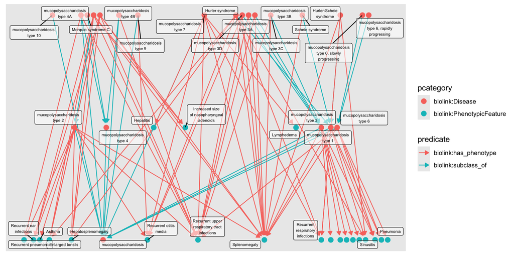

```r
ggraph(mps_immune_phenos, layout = "sugiyama") +
    geom_edge_link(aes(color = predicate),
                                 arrow = arrow(length = unit(2, 'mm'), type = "closed"),
                                 end_cap = circle(2.5, 'mm')) +
    geom_node_point(aes(color = pcategory),
                                    size = 3) +
    geom_node_label(aes(label = str_wrap(name, 20)),
                                    size = 2,
                                    repel = TRUE,
                                    check_overlap = TRUE,
                                    fill = "#FFFFFF88")
```